# Module 70

#### Contrast SVE:

Signed variance explained (SVE) provides an indication of how similar a set of fold changes are to a gene module’s weight vector. An SVE value of 0.3, for example, indicates that 30% of the variance explained by the entire module set is accounted for by the module in question. Shown here are the SVE values for this module across a compendium of fold changes (contrasts). Extreme SVE values (e.g., > 0.05) indicate that those contrasts specifically induce (orange dots) or specifically repress (blue dots) this module. Examining the experimental conditions being compared in such contrasts (see tables below the figure) may provide insight into the gene module’s function.

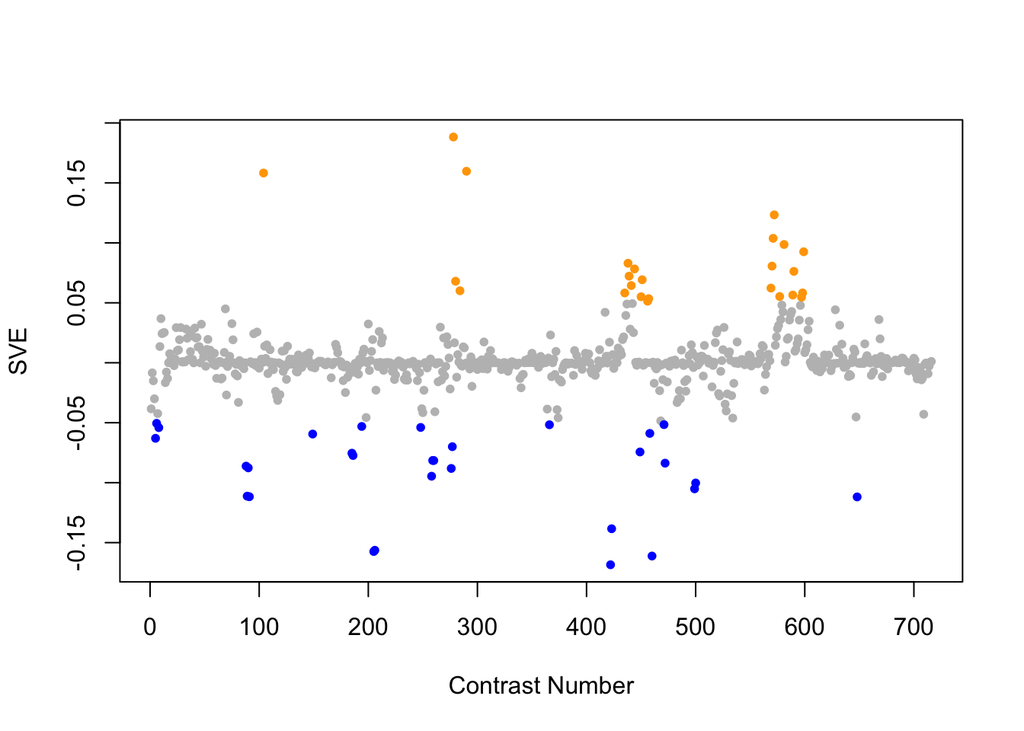

Positive SVE Contrasts:

|  | Contrast.Num | SVE | GEO.GSE | Cond.1 | Cond.2 | Mutation |
| --- | --- | --- | --- | --- | --- | --- |
| GSE41366B.s1t3.vs.s0t3 | 278 | 0.19 | GSE41366 | low_DDVP-8h_expose-26h_harvest-rep1 | control-8h_expose-26h_harvest-rep1 |  |
| GSE41366C.s1t5.vs.s0t5 | 290 | 0.16 | GSE41366 | low_DDVP-continuous_expose-26h_harvest-rep1 | control-continuous_expose-20h_harvest-rep1 |  |
| GSE57664.s1t1.vs.s0t1 | 104 | 0.16 | GSE57664 | TYR treated rep1 | control rep1 |  |
| GSE2180.s1t10.vs.s1t1 | 572 | 0.12 | GSE2180 | 186-1 | 00B |  |
| GSE2180.s1t9.vs.s1t1 | 571 | 0.10 | GSE2180 | 143L | 00B |  |
| GSE2180.s2t10.vs.s2t1 | 581 | 0.10 | GSE2180 | ms186-5 | ms0-1 |  |
| GSE2180.s4t10.vs.s4t1 | 599 | 0.09 | GSE2180 | pp186-1 | pp0-1 |  |
| GSE27677B.s1t6.vs.s1t1 | 438 | 0.08 | GSE27677 | N2, Fast 18 h, rep 1 | N2, Fed 0 h, rep 1 |  |
| GSE2180.s1t8.vs.s1t1 | 570 | 0.08 | GSE2180 | 122-1 | 00B |  |
| GSE27677B.s1t4.vs.s1t1 | 444 | 0.08 | GSE27677 | N2, Fast 9 h, rep 1 | N2, Fed 0 h, rep 1 |  |
| GSE2180.s3t10.vs.s3t1 | 590 | 0.08 | GSE2180 | p186-2 | p0-3 |  |
| GSE27677B.s1t7.vs.s1t1 | 439 | 0.07 | GSE27677 | N2, Fast 24 h, rep 1 | N2, Fed 0 h, rep 1 |  |
| GSE25633.s1t1.vs.s3t1 | 451 | 0.07 | GSE25633 | WT#1 | daf-12#1 | daf-12 |
| GSE41366B.s0t3.vs.s0t1 | 280 | 0.07 | GSE41366 | control-8h_expose-26h_harvest-rep1 | control-8h_expose-14h_harvest-rep1 |  |
| GSE27677B.s1t8.vs.s1t1 | 441 | 0.06 | GSE27677 | N2, Fast 36 h, rep 1 | N2, Fed 0 h, rep 1 |  |
| GSE2180.s1t7.vs.s1t1 | 569 | 0.06 | GSE2180 | 101G | 00B |  |
| GSE41366B.s1t3.vs.s1t1 | 284 | 0.06 | GSE41366 | low_DDVP-8h_expose-26h_harvest-rep1 | low_DDVP-8h_expose-14h_harvest-rep1 |  |
| GSE2180.s4t9.vs.s4t1 | 598 | 0.06 | GSE2180 | pp143-1 | pp0-1 |  |
| GSE27677B.s1t7.vs.s0t7 | 435 | 0.06 | GSE27677 | N2, Fast 24 h, rep 1 | N2, Fed 24 h, rep 1 |  |
| GSE2180.s3t9.vs.s3t1 | 589 | 0.06 | GSE2180 | p143-2 | p0-3 |  |
| GSE2180.s1t6.vs.s1t1 | 577 | 0.06 | GSE2180 | 83-1 | 00B |  |
| GSE25633.s2t1.vs.s3t1 | 450 | 0.06 | GSE25633 | daf-19,daf-12#1 | daf-12#1 | daf-19 |
| GSE2180.s4t8.vs.s4t1 | 597 | 0.05 | GSE2180 | pp122-1 | pp0-1 |  |
| GSE24847.s1t3.vs.s1t1 | 457 | 0.05 | GSE24847 | young adult_4hr MWCNT exposure_rep1 | young adult_0h MWCNT exposure_rep1 |  |
| GSE24847.s1t2.vs.s1t1 | 456 | 0.05 | GSE24847 | young adult_24hr MWCNT exposure_rep1 | young adult_0h MWCNT exposure_rep1 |  |

Negative SVE Contrasts:

|  | Contrast.Num | SVE | GEO.GSE | Cond.1 | Cond.2 | Mutation |
| --- | --- | --- | --- | --- | --- | --- |
| GSE28494.s1t2.vs.s1t1 | 422 | -0.17 | GSE28494 | lin-54(n3423) dissected germline 1 | lin-54(n2990) embryo 1 |  |
| GSE23843C.s1t1.vs.s0t1 | 460 | -0.16 | GSE23843 | gld-2(RNAi), biological replicate 1 | wild-type total RNA, biological replicate 1 | gld-2 |
| GSE42703.s2t1.vs.s1t1 | 205 | -0.16 | GSE42703 | WT incubated with 1mM copper sulfate, biological rep1 | kgb-1 incubated with 1mM copper sulfate, biological rep1 | kgb-1 |
| GSE42703.s2t2.vs.s1t2 | 206 | -0.16 | GSE42703 | WT incubated with H2O, biological rep1 | kgb-1 incubated with H2O, biological rep1 | kgb-1 |
| GSE28494.s0t2.vs.s0t1 | 423 | -0.14 | GSE28494 | wild-type N2 dissected germline 1 | wild-type N2 embryo 1 |  |
| GSE16753.s1t1.vs.s0t1 | 648 | -0.11 | GSE16753 | fer-1 (hc24ts) mutant young adult biological rep 1 | Wild-type young adult biological rep 3 | fer-1 |
| GSE6547.s1t3.vs.s1t1 | 91 | -0.11 | GSE6547 | lin-35(n745) worms at L4 stage, first replicate | lin-35(n745) worms at embryonic stage, first replicate |  |
| GSE6547.s0t3.vs.s0t1 | 89 | -0.11 | GSE6547 | N2 (wt) worms at L4 stage, first replicate | N2 (wt) worms at embryonic stage, first replicate |  |
| GSE23013.s3t1.vs.s0t1 | 499 | -0.11 | GSE23013 | young adult_24hr BTF mix exposure_rep1 | young adult_not exposed_rep1 |  |
| GSE23013.s2t1.vs.s0t1 | 500 | -0.10 | GSE23013 | young adult_24hr Formaldehyde exposure_rep1 | young adult_not exposed_rep1 |  |
| GSE41366A.s2t3.vs.s0t3 | 258 | -0.09 | GSE41366 | high_DDVP-2h_expose-20h_harvest-rep1 | control-2h_expose-20h_harvest-rep1 |  |
| GSE41366B.s1t2.vs.s0t2 | 276 | -0.09 | GSE41366 | low_DDVP-8h_expose-20h_harvest-rep1 | control-8h_expose-20h_harvest-rep1 |  |
| GSE6547.s1t2.vs.s1t1 | 90 | -0.09 | GSE6547 | lin-35(n745) worms at L1 stage, first replicate | lin-35(n745) worms at embryonic stage, first replicate |  |
| GSE6547.s0t2.vs.s0t1 | 88 | -0.09 | GSE6547 | N2 (wt) worms at L1 stage, first replicate | N2 (wt) worms at embryonic stage, first replicate |  |
| GSE23528A.s2t2.vs.s0t2 | 472 | -0.08 | GSE23528 | Adult at T6 in WC, time-series experiment 1 | Adult at T6, non-entrained control time-series experiment 4 |  |
| GSE41366A.s2t4.vs.s0t4 | 260 | -0.08 | GSE41366 | high_DDVP-2h_expose-26h_harvest-rep1 | control-2h_expose-26h_harvest-rep1 |  |
| GSE41366A.s1t3.vs.s0t3 | 259 | -0.08 | GSE41366 | low_DDVP-2h_expose-20h_harvest-rep1 | control-2h_expose-20h_harvest-rep1 |  |
| GSE4766.s1t2.vs.s1t1 | 186 | -0.08 | GSE4766 | Pooled glp-1 C elegans young adults_rep1 | Pooled glp-1 C elegans embryos_bleach NaOH prep_rep1 |  |
| GSE4766.s1t3.vs.s1t1 | 185 | -0.08 | GSE4766 | Pooled glp-1 C elegans old adults_rep1 | Pooled glp-1 C elegans embryos_bleach NaOH prep_rep1 |  |
| GSE25831.s1t1.vs.s2t1 | 449 | -0.07 | GSE25831 | WT_fedL1_rep1 | mixed embryo XX_WT-N_080307_A |  |
| GSE41366B.s2t3.vs.s0t3 | 277 | -0.07 | GSE41366 | high_DDVP-8h_expose-26h_harvest-rep1 | control-8h_expose-26h_harvest-rep1 |  |
| GSE9897B.s2t1.vs.s0t1 | 5 | -0.06 | GSE9897 | Complex I RNAi Mutant 2 | Wildtype (control for RNAi) | Y45G12B.1 |
| GSE48347.s1t1.vs.s0t1 | 149 | -0.06 | GSE48347 | smo1_embryo_rep1 | WT_embryo_rep1 | smo-1 |
| GSE23843A.s1t1.vs.s0t1 | 458 | -0.06 | GSE23843 | GLD-2 gld-2(RNAi)-IP, biological replicate 1 | GLD-2 wt-IP, biological replicate 1 |  |
| GSE9897B.s5t1.vs.s0t1 | 8 | -0.05 | GSE9897 | Complex I RNAi Mutant 5 | Wildtype (control for RNAi) | D2030.4 |
| GSE42192.s1t2.vs.s0t2 | 248 | -0.05 | GSE42192 | C.elegans fed with CNCM I-3690 10 days rep1 | C.elegans fed with E.coli OP50 10 days rep1 |  |
| GSE44318.s1t1.vs.s0t1 | 194 | -0.05 | GSE44318 | 13L peptide [SL12] | NGM [SL1] |  |
| GSE36358.s4t1.vs.s0t1 | 366 | -0.05 | GSE36358 | Space Flight | Ground Control (Tsukuba space center) |  |
| GSE23528A.s1t2.vs.s0t2 | 471 | -0.05 | GSE23528 | Adult at T6 in LD, time-series experiment 3 | Adult at T6, non-entrained control time-series experiment 4 |  |
| GSE9897B.s3t1.vs.s0t1 | 6 | -0.05 | GSE9897 | Complex I RNAi Mutant 3 | Wildtype (control for RNAi) | C34B2.8 |

$~$

#### Contrast SVE, Up-Regulated Genes Only:

Calculating SVE for up-regulated and down-regulated genes separately may be more informative in many cases than projecting the up- and down- gene sets together. This is due to the fact that the weight distribution of many modules is highly skewed, indicating that only one of the hemi-modules may be biologically meaningful (i.e., a set of genes are strongly correlated by only a few genes (or none) are strongly anti-correlated to that set.)

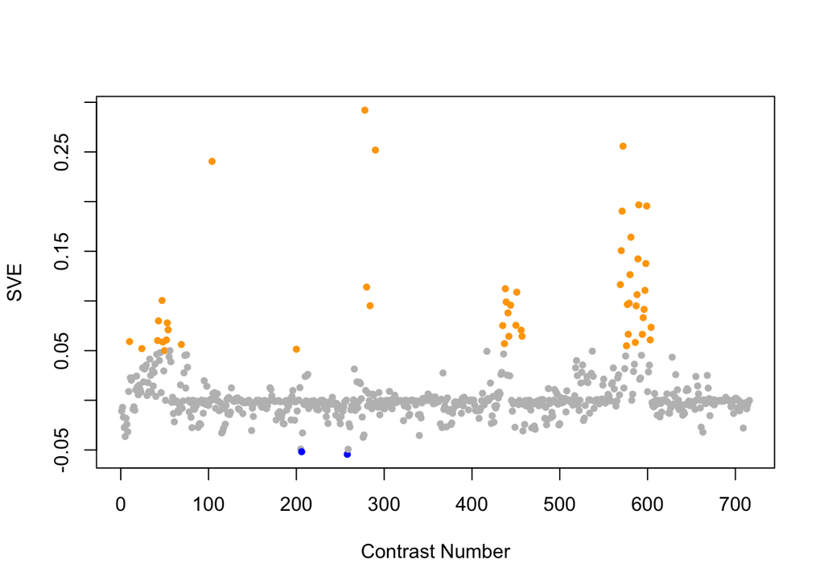

Positive SVE Contrasts:

|  | Contrast.Num | SVE | GEO.GSE | Cond.1 | Cond.2 | Mutation |
| --- | --- | --- | --- | --- | --- | --- |
| GSE41366B.s1t3.vs.s0t3 | 278 | 0.29 | GSE41366 | low_DDVP-8h_expose-26h_harvest-rep1 | control-8h_expose-26h_harvest-rep1 |  |
| GSE2180.s1t10.vs.s1t1 | 572 | 0.26 | GSE2180 | 186-1 | 00B |  |
| GSE41366C.s1t5.vs.s0t5 | 290 | 0.25 | GSE41366 | low_DDVP-continuous_expose-26h_harvest-rep1 | control-continuous_expose-20h_harvest-rep1 |  |
| GSE57664.s1t1.vs.s0t1 | 104 | 0.24 | GSE57664 | TYR treated rep1 | control rep1 |  |
| GSE2180.s3t10.vs.s3t1 | 590 | 0.20 | GSE2180 | p186-2 | p0-3 |  |
| GSE2180.s4t10.vs.s4t1 | 599 | 0.20 | GSE2180 | pp186-1 | pp0-1 |  |
| GSE2180.s1t9.vs.s1t1 | 571 | 0.19 | GSE2180 | 143L | 00B |  |
| GSE2180.s2t10.vs.s2t1 | 581 | 0.16 | GSE2180 | ms186-5 | ms0-1 |  |
| GSE2180.s1t8.vs.s1t1 | 570 | 0.15 | GSE2180 | 122-1 | 00B |  |
| GSE2180.s3t9.vs.s3t1 | 589 | 0.14 | GSE2180 | p143-2 | p0-3 |  |
| GSE2180.s4t9.vs.s4t1 | 598 | 0.14 | GSE2180 | pp143-1 | pp0-1 |  |
| GSE2180.s2t9.vs.s2t1 | 580 | 0.13 | GSE2180 | ms143-2 | ms0-1 |  |
| GSE2180.s1t7.vs.s1t1 | 569 | 0.12 | GSE2180 | 101G | 00B |  |
| GSE41366B.s0t3.vs.s0t1 | 280 | 0.11 | GSE41366 | control-8h_expose-26h_harvest-rep1 | control-8h_expose-14h_harvest-rep1 |  |
| GSE27677B.s1t6.vs.s1t1 | 438 | 0.11 | GSE27677 | N2, Fast 18 h, rep 1 | N2, Fed 0 h, rep 1 |  |
| GSE2180.s4t8.vs.s4t1 | 597 | 0.11 | GSE2180 | pp122-1 | pp0-1 |  |
| GSE25633.s1t1.vs.s3t1 | 451 | 0.11 | GSE25633 | WT#1 | daf-12#1 | daf-12 |
| GSE2180.s3t8.vs.s3t1 | 588 | 0.11 | GSE2180 | p122-2 | p0-3 |  |
| GSE9665.s4t2.vs.s4t1 | 47 | 0.10 | GSE9665 | mex-3 hnd-1 186 A | mex-3 hnd-1 143 A |  |
| GSE27677B.s1t7.vs.s1t1 | 439 | 0.10 | GSE27677 | N2, Fast 24 h, rep 1 | N2, Fed 0 h, rep 1 |  |
| GSE2180.s2t8.vs.s2t1 | 579 | 0.10 | GSE2180 | ms122-1 | ms0-1 |  |
| GSE2180.s1t6.vs.s1t1 | 577 | 0.10 | GSE2180 | 83-1 | 00B |  |
| GSE27677B.s1t4.vs.s1t1 | 444 | 0.10 | GSE27677 | N2, Fast 9 h, rep 1 | N2, Fed 0 h, rep 1 |  |
| GSE41366B.s1t3.vs.s1t1 | 284 | 0.10 | GSE41366 | low_DDVP-8h_expose-26h_harvest-rep1 | low_DDVP-8h_expose-14h_harvest-rep1 |  |
| GSE2180.s3t7.vs.s3t1 | 587 | 0.10 | GSE2180 | p101-2 | p0-3 |  |
| GSE2180.s4t7.vs.s4t1 | 596 | 0.09 | GSE2180 | pp101-1 | pp0-1 |  |
| GSE27677B.s1t8.vs.s1t1 | 441 | 0.09 | GSE27677 | N2, Fast 36 h, rep 1 | N2, Fed 0 h, rep 1 |  |
| GSE2180.s3t6.vs.s3t1 | 595 | 0.08 | GSE2180 | p83-2 | p0-3 |  |
| GSE9665.s0t3.vs.s0t1 | 43 | 0.08 | GSE9665 | mex-3 230 A | mex-3 143 A |  |
| GSE9665.s8t3.vs.s8t1 | 53 | 0.08 | GSE9665 | mex-3 pal-1 230 A | mex-3 pal-1 143 A |  |
| GSE25633.s2t1.vs.s3t1 | 450 | 0.08 | GSE25633 | daf-19,daf-12#1 | daf-12#1 | daf-19 |
| GSE27677B.s1t7.vs.s0t7 | 435 | 0.08 | GSE27677 | N2, Fast 24 h, rep 1 | N2, Fed 24 h, rep 1 |  |
| GSE2180.s4t6.vs.s4t1 | 604 | 0.07 | GSE2180 | pp83-1 | pp0-1 |  |
| GSE9665.s9t2.vs.s9t1 | 54 | 0.07 | GSE9665 | mex-3 scrt-1 186 A | mex-3 scrt-1 143 A |  |
| GSE24847.s1t2.vs.s1t1 | 456 | 0.07 | GSE24847 | young adult_24hr MWCNT exposure_rep1 | young adult_0h MWCNT exposure_rep1 |  |
| GSE2180.s2t7.vs.s2t1 | 578 | 0.07 | GSE2180 | ms101-2 | ms0-1 |  |
| GSE2180.s3t5.vs.s3t1 | 594 | 0.07 | GSE2180 | p66-1 | p0-3 |  |
| GSE24847.s1t3.vs.s1t1 | 457 | 0.06 | GSE24847 | young adult_4hr MWCNT exposure_rep1 | young adult_0h MWCNT exposure_rep1 |  |
| GSE27677B.s1t9.vs.s1t1 | 442 | 0.06 | GSE27677 | N2, Fast 48 h, rep 1 | N2, Fed 0 h, rep 1 |  |
| GSE2180.s4t5.vs.s4t1 | 603 | 0.06 | GSE2180 | pp66-1 | pp0-1 |  |
| GSE9665.s8t2.vs.s8t1 | 52 | 0.06 | GSE9665 | mex-3 pal-1 186 A | mex-3 pal-1 143 A |  |
| GSE9665.s0t2.vs.s0t1 | 42 | 0.06 | GSE9665 | mex-3 186 A | mex-3 143 A |  |
| GSE9682.s1t1.vs.s0t1 | 10 | 0.06 | GSE9682 | N2-Cel-RhebRNAi-fasting-biological rep1 | N2-controlRNAi-fasting-biological rep1 | Rheb |
| GSE9665.s5t3.vs.s5t2 | 48 | 0.06 | GSE9665 | mex-3 lin-26 230 A | mex-3 lin-26 186 A |  |
| GSE2180.s2t6.vs.s2t1 | 586 | 0.06 | GSE2180 | ms83-5 | ms0-1 |  |
| GSE27677B.s1t5.vs.s1t1 | 437 | 0.06 | GSE27677 | N2, Fast 12 h, rep 1 | N2, Fed 0 h, rep 1 |  |
| GSE8462.s2t2.vs.s1t2 | 69 | 0.06 | GSE8462 | 24 hr Reference, biological rep 1 | 24 hr muscle, biological rep 1 |  |
| GSE2180.s1t5.vs.s1t1 | 576 | 0.05 | GSE2180 | 66-4 | 00B |  |
| GSE9665.s3t2.vs.s0t2 | 24 | 0.05 | GSE9665 | mex-3 hlh-1 186 A | mex-3 186 A | hlh-1 |
| GSE43959.s1t2.vs.s3t2 | 200 | 0.05 | GSE43959 | N2 gravid adult on E. coli OP50 rep 1 | N2 gravid adult on Comamonas DA1877 rep 1 |  |
| GSE9665.s7t3.vs.s7t2 | 50 | 0.05 | GSE9665 | mex-3 nob-1 230 A | mex-3 nob-1 186 A |  |

Negative SVE Contrasts:

|  | Contrast.Num | SVE | GEO.GSE | Cond.1 | Cond.2 | Mutation |
| --- | --- | --- | --- | --- | --- | --- |
| GSE41366A.s2t3.vs.s0t3 | 258 | -0.05 | GSE41366 | high_DDVP-2h_expose-20h_harvest-rep1 | control-2h_expose-20h_harvest-rep1 |  |
| GSE42703.s2t2.vs.s1t2 | 206 | -0.05 | GSE42703 | WT incubated with H2O, biological rep1 | kgb-1 incubated with H2O, biological rep1 | kgb-1 |
| GSE41366A.s1t3.vs.s0t3 | 259 | -0.05 | GSE41366 | low_DDVP-2h_expose-20h_harvest-rep1 | control-2h_expose-20h_harvest-rep1 |  |
| GSE42703.s2t1.vs.s1t1 | 205 | -0.05 | GSE42703 | WT incubated with 1mM copper sulfate, biological rep1 | kgb-1 incubated with 1mM copper sulfate, biological rep1 | kgb-1 |
| GSE41366B.s1t2.vs.s0t2 | 276 | -0.04 | GSE41366 | low_DDVP-8h_expose-20h_harvest-rep1 | control-8h_expose-20h_harvest-rep1 |  |

$~$

#### Contrast SVE, Down-Regulated Genes Only:

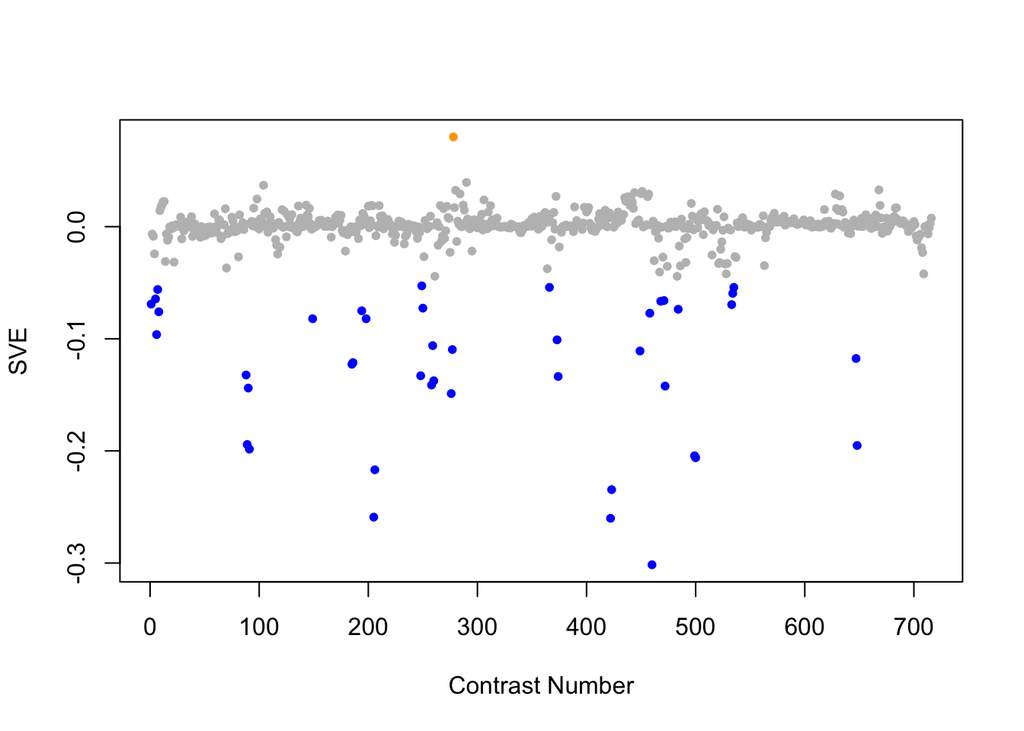

Positive SVE Contrasts:

|  | Contrast.Num | SVE | GEO.GSE | Cond.1 | Cond.2 | Mutation |
| --- | --- | --- | --- | --- | --- | --- |
| GSE41366B.s1t3.vs.s0t3 | 278 | 0.08 | GSE41366 | low_DDVP-8h_expose-26h_harvest-rep1 | control-8h_expose-26h_harvest-rep1 |  |
| GSE41366C.s1t5.vs.s0t5 | 290 | 0.04 | GSE41366 | low_DDVP-continuous_expose-26h_harvest-rep1 | control-continuous_expose-20h_harvest-rep1 |  |
| GSE57664.s1t1.vs.s0t1 | 104 | 0.04 | GSE57664 | TYR treated rep1 | control rep1 |  |
| GSE15016.s4t1.vs.s0t1 | 668 | 0.03 | GSE15016 | young adult_24hr BPA exposure_rep1 | young adult_not exposured_rep1 |  |
| GSE41366B.s0t3.vs.s0t1 | 280 | 0.03 | GSE41366 | control-8h_expose-26h_harvest-rep1 | control-8h_expose-14h_harvest-rep1 |  |

Negative SVE Contrasts:

|  | Contrast.Num | SVE | GEO.GSE | Cond.1 | Cond.2 | Mutation |
| --- | --- | --- | --- | --- | --- | --- |
| GSE23843C.s1t1.vs.s0t1 | 460 | -0.30 | GSE23843 | gld-2(RNAi), biological replicate 1 | wild-type total RNA, biological replicate 1 | gld-2 |
| GSE28494.s1t2.vs.s1t1 | 422 | -0.26 | GSE28494 | lin-54(n3423) dissected germline 1 | lin-54(n2990) embryo 1 |  |
| GSE42703.s2t1.vs.s1t1 | 205 | -0.26 | GSE42703 | WT incubated with 1mM copper sulfate, biological rep1 | kgb-1 incubated with 1mM copper sulfate, biological rep1 | kgb-1 |
| GSE28494.s0t2.vs.s0t1 | 423 | -0.23 | GSE28494 | wild-type N2 dissected germline 1 | wild-type N2 embryo 1 |  |
| GSE42703.s2t2.vs.s1t2 | 206 | -0.22 | GSE42703 | WT incubated with H2O, biological rep1 | kgb-1 incubated with H2O, biological rep1 | kgb-1 |
| GSE23013.s2t1.vs.s0t1 | 500 | -0.21 | GSE23013 | young adult_24hr Formaldehyde exposure_rep1 | young adult_not exposed_rep1 |  |
| GSE23013.s3t1.vs.s0t1 | 499 | -0.20 | GSE23013 | young adult_24hr BTF mix exposure_rep1 | young adult_not exposed_rep1 |  |
| GSE6547.s1t3.vs.s1t1 | 91 | -0.20 | GSE6547 | lin-35(n745) worms at L4 stage, first replicate | lin-35(n745) worms at embryonic stage, first replicate |  |
| GSE16753.s1t1.vs.s0t1 | 648 | -0.20 | GSE16753 | fer-1 (hc24ts) mutant young adult biological rep 1 | Wild-type young adult biological rep 3 | fer-1 |
| GSE6547.s0t3.vs.s0t1 | 89 | -0.19 | GSE6547 | N2 (wt) worms at L4 stage, first replicate | N2 (wt) worms at embryonic stage, first replicate |  |
| GSE41366B.s1t2.vs.s0t2 | 276 | -0.15 | GSE41366 | low_DDVP-8h_expose-20h_harvest-rep1 | control-8h_expose-20h_harvest-rep1 |  |
| GSE6547.s1t2.vs.s1t1 | 90 | -0.14 | GSE6547 | lin-35(n745) worms at L1 stage, first replicate | lin-35(n745) worms at embryonic stage, first replicate |  |
| GSE23528A.s2t2.vs.s0t2 | 472 | -0.14 | GSE23528 | Adult at T6 in WC, time-series experiment 1 | Adult at T6, non-entrained control time-series experiment 4 |  |
| GSE41366A.s2t3.vs.s0t3 | 258 | -0.14 | GSE41366 | high_DDVP-2h_expose-20h_harvest-rep1 | control-2h_expose-20h_harvest-rep1 |  |
| GSE41366A.s2t4.vs.s0t4 | 260 | -0.14 | GSE41366 | high_DDVP-2h_expose-26h_harvest-rep1 | control-2h_expose-26h_harvest-rep1 |  |
| GSE35354A.s1t4.vs.s1t1 | 374 | -0.13 | GSE35354 | Q200_rep1 | Q control_rep1 |  |
| GSE42192.s1t2.vs.s0t2 | 248 | -0.13 | GSE42192 | C.elegans fed with CNCM I-3690 10 days rep1 | C.elegans fed with E.coli OP50 10 days rep1 |  |
| GSE6547.s0t2.vs.s0t1 | 88 | -0.13 | GSE6547 | N2 (wt) worms at L1 stage, first replicate | N2 (wt) worms at embryonic stage, first replicate |  |
| GSE4766.s1t3.vs.s1t1 | 185 | -0.12 | GSE4766 | Pooled glp-1 C elegans old adults_rep1 | Pooled glp-1 C elegans embryos_bleach NaOH prep_rep1 |  |
| GSE4766.s1t2.vs.s1t1 | 186 | -0.12 | GSE4766 | Pooled glp-1 C elegans young adults_rep1 | Pooled glp-1 C elegans embryos_bleach NaOH prep_rep1 |  |
| GSE16753.s2t1.vs.s0t1 | 647 | -0.12 | GSE16753 | fer-1 (hc1ts) mutant young adult biological rep 1 | Wild-type young adult biological rep 3 | fer-1 |
| GSE25831.s1t1.vs.s2t1 | 449 | -0.11 | GSE25831 | WT_fedL1_rep1 | mixed embryo XX_WT-N_080307_A |  |
| GSE41366B.s2t3.vs.s0t3 | 277 | -0.11 | GSE41366 | high_DDVP-8h_expose-26h_harvest-rep1 | control-8h_expose-26h_harvest-rep1 |  |
| GSE41366A.s1t3.vs.s0t3 | 259 | -0.11 | GSE41366 | low_DDVP-2h_expose-20h_harvest-rep1 | control-2h_expose-20h_harvest-rep1 |  |
| GSE35354A.s1t3.vs.s1t1 | 373 | -0.10 | GSE35354 | Q100_rep1 | Q control_rep1 |  |
| GSE9897B.s3t1.vs.s0t1 | 6 | -0.10 | GSE9897 | Complex I RNAi Mutant 3 | Wildtype (control for RNAi) | C34B2.8 |
| GSE48347.s1t1.vs.s0t1 | 149 | -0.08 | GSE48347 | smo1_embryo_rep1 | WT_embryo_rep1 | smo-1 |
| GSE43959.s3t2.vs.s4t2 | 198 | -0.08 | GSE43959 | N2 gravid adult on Comamonas DA1877 rep 1 | N2 gravid adult on 1:1000 Comamonas DA1877 rep 1 |  |
| GSE23843A.s1t1.vs.s0t1 | 458 | -0.08 | GSE23843 | GLD-2 gld-2(RNAi)-IP, biological replicate 1 | GLD-2 wt-IP, biological replicate 1 |  |
| GSE9897B.s5t1.vs.s0t1 | 8 | -0.08 | GSE9897 | Complex I RNAi Mutant 5 | Wildtype (control for RNAi) | D2030.4 |
| GSE44318.s1t1.vs.s0t1 | 194 | -0.08 | GSE44318 | 13L peptide [SL12] | NGM [SL1] |  |
| GSE23528A.s0t4.vs.s0t1 | 484 | -0.07 | GSE23528 | Adult at T14, non-entrained control time-series experiment 4 | Adult at T2, non-entrained control time-series experiment 4 |  |
| GSE42192.s1t1.vs.s0t1 | 250 | -0.07 | GSE42192 | C.elegans fed with CNCM I-3690 3 days rep1 | C.elegans fed with E.coli OP50 3 days rep1 |  |
| GSE2180.s2t10.vs.s1t10 | 533 | -0.07 | GSE2180 | ms186-5 | 186-1 | mex-3(zu155);skn-1(RNAi) |
| GSE9897A.s1t1.vs.s0t1 | 1 | -0.07 | GSE9897 | Complex I missense mutant | Wildtype (control for missense) | gas-1 |
| GSE23528A.s2t1.vs.s0t1 | 468 | -0.07 | GSE23528 | Adult at T2 in WC, time-series experiment 1 | Adult at T2, non-entrained control time-series experiment 4 |  |
| GSE23528A.s1t2.vs.s0t2 | 471 | -0.07 | GSE23528 | Adult at T6 in LD, time-series experiment 3 | Adult at T6, non-entrained control time-series experiment 4 |  |
| GSE9897B.s2t1.vs.s0t1 | 5 | -0.06 | GSE9897 | Complex I RNAi Mutant 2 | Wildtype (control for RNAi) | Y45G12B.1 |
| GSE2180.s3t10.vs.s1t10 | 534 | -0.06 | GSE2180 | p186-2 | 186-1 | pie-1(zu154) |
| GSE9897B.s4t1.vs.s0t1 | 7 | -0.06 | GSE9897 | Complex I RNAi Mutant 4 | Wildtype (control for RNAi) | Y56A3A.19 |
| GSE36358.s4t1.vs.s0t1 | 366 | -0.05 | GSE36358 | Space Flight | Ground Control (Tsukuba space center) |  |
| GSE2180.s4t10.vs.s1t10 | 535 | -0.05 | GSE2180 | pp186-1 | 186-1 | pie-1(zu154);pal-1(RNAi) |
| GSE42192.s2t2.vs.s0t2 | 249 | -0.05 | GSE42192 | C.elegans fed with CNCM I-4317 10 days rep1 | C.elegans fed with E.coli OP50 10 days rep1 |  |

$~$

$~$

#### GO Term Enrichment:

This analysis tests each hemi-module for enrichment of specific GO terms. Only gene-level annotations (e.g., as would be found on the gene’s page in Wormbase) are tested - the hierarchical structure of the GO ontology is not taken into account.

*Note: At least the top two most enriched terms from each GO domain (BP/MF/CC) are shown, even when not statistically significant.*

##### Enriched GO terms: Hemi-module A

| ID | GO.Term | GO Domain | Raw p-value | Adj p-value |
| --- | --- | --- | --- | --- |
| [GO_0045944](http://amigo.geneontology.org/amigo/term/GO:0045944) | positive regulation of transcription by RNA polymerase II | BP | 1.37e-11 | 3.66e-08 |
| [GO_0006357](http://amigo.geneontology.org/amigo/term/GO:0006357) | regulation of transcription by RNA polymerase II | BP | 2.01e-11 | 3.66e-08 |
| [GO_0001764](http://amigo.geneontology.org/amigo/term/GO:0001764) | neuron migration | BP | 3.62e-11 | 4.40e-08 |
| [GO_0007275](http://amigo.geneontology.org/amigo/term/GO:0007275) | multicellular organism development | BP | 6.55e-11 | 5.96e-08 |
| [GO_0006355](http://amigo.geneontology.org/amigo/term/GO:0006355) | regulation of transcription, DNA-templated | BP | 4.82e-09 | 3.51e-06 |
| [GO_0007399](http://amigo.geneontology.org/amigo/term/GO:0007399) | nervous system development | BP | 8.49e-09 | 5.15e-06 |
| [GO_0000122](http://amigo.geneontology.org/amigo/term/GO:0000122) | negative regulation of transcription by RNA polymerase II | BP | 2.83e-08 | 1.47e-05 |
| [GO_0030182](http://amigo.geneontology.org/amigo/term/GO:0030182) | neuron differentiation | BP | 1.93e-07 | 8.79e-05 |
| [GO_0097376](http://amigo.geneontology.org/amigo/term/GO:0097376) | interneuron axon guidance | BP | 4.89e-07 | 1.98e-04 |
| [GO_0009888](http://amigo.geneontology.org/amigo/term/GO:0009888) | tissue development | BP | 4.51e-06 | 1.64e-03 |
| [GO_0007411](http://amigo.geneontology.org/amigo/term/GO:0007411) | axon guidance | BP | 9.84e-06 | 3.26e-03 |
| [GO_0048665](http://amigo.geneontology.org/amigo/term/GO:0048665) | neuron fate specification | BP | 1.91e-05 | 4.98e-03 |
| [GO_0097475](http://amigo.geneontology.org/amigo/term/GO:0097475) | motor neuron migration | BP | 1.91e-05 | 4.98e-03 |
| [GO_1905485](http://amigo.geneontology.org/amigo/term/GO:1905485) | positive regulation of motor neuron migration | BP | 1.91e-05 | 4.98e-03 |
| [GO_0033564](http://amigo.geneontology.org/amigo/term/GO:0033564) | anterior/posterior axon guidance | BP | 5.48e-05 | 1.25e-02 |
| [GO_0050775](http://amigo.geneontology.org/amigo/term/GO:0050775) | positive regulation of dendrite morphogenesis | BP | 5.48e-05 | 1.25e-02 |
| [GO_0030154](http://amigo.geneontology.org/amigo/term/GO:0030154) | cell differentiation | BP | 5.84e-05 | 1.25e-02 |
| [GO_0007501](http://amigo.geneontology.org/amigo/term/GO:0007501) | mesodermal cell fate specification | BP | 6.25e-05 | 1.26e-02 |
| [GO_0006334](http://amigo.geneontology.org/amigo/term/GO:0006334) | nucleosome assembly | BP | 8.62e-05 | 1.52e-02 |
| [GO_0097402](http://amigo.geneontology.org/amigo/term/GO:0097402) | neuroblast migration | BP | 8.62e-05 | 1.52e-02 |
| [GO_0002119](http://amigo.geneontology.org/amigo/term/GO:0002119) | nematode larval development | BP | 8.76e-05 | 1.52e-02 |
| [GO_0009653](http://amigo.geneontology.org/amigo/term/GO:0009653) | anatomical structure morphogenesis | BP | 1.52e-04 | 2.52e-02 |
| [GO_0001708](http://amigo.geneontology.org/amigo/term/GO:0001708) | cell fate specification | BP | 2.66e-04 | 3.70e-02 |
| [GO_0016584](http://amigo.geneontology.org/amigo/term/GO:0016584) | nucleosome positioning | BP | 2.95e-04 | 3.70e-02 |
| [GO_0031175](http://amigo.geneontology.org/amigo/term/GO:0031175) | neuron projection development | BP | 2.95e-04 | 3.70e-02 |
| [GO_0031936](http://amigo.geneontology.org/amigo/term/GO:0031936) | negative regulation of chromatin silencing | BP | 2.95e-04 | 3.70e-02 |
| [GO_0048730](http://amigo.geneontology.org/amigo/term/GO:0048730) | epidermis morphogenesis | BP | 2.95e-04 | 3.70e-02 |
| [GO_0097374](http://amigo.geneontology.org/amigo/term/GO:0097374) | sensory neuron axon guidance | BP | 2.95e-04 | 3.70e-02 |
| [GO_1904936](http://amigo.geneontology.org/amigo/term/GO:1904936) | interneuron migration | BP | 2.95e-04 | 3.70e-02 |
| [GO_1903861](http://amigo.geneontology.org/amigo/term/GO:1903861) | positive regulation of dendrite extension | BP | 3.18e-04 | 3.86e-02 |
| [GO_0016055](http://amigo.geneontology.org/amigo/term/GO:0016055) | Wnt signaling pathway | BP | 4.76e-04 | 5.42e-02 |
| [GO_0045138](http://amigo.geneontology.org/amigo/term/GO:0045138) | nematode male tail tip morphogenesis | BP | 4.76e-04 | 5.42e-02 |
| [GO_0033563](http://amigo.geneontology.org/amigo/term/GO:0033563) | dorsal/ventral axon guidance | BP | 5.63e-04 | 6.03e-02 |
| [GO_0098609](http://amigo.geneontology.org/amigo/term/GO:0098609) | cell-cell adhesion | BP | 5.63e-04 | 6.03e-02 |
| [GO_0008078](http://amigo.geneontology.org/amigo/term/GO:0008078) | mesodermal cell migration | BP | 6.15e-04 | 6.06e-02 |
| [GO_0045910](http://amigo.geneontology.org/amigo/term/GO:0045910) | negative regulation of DNA recombination | BP | 6.15e-04 | 6.06e-02 |
| [GO_0048337](http://amigo.geneontology.org/amigo/term/GO:0048337) | positive regulation of mesodermal cell fate specification | BP | 6.15e-04 | 6.06e-02 |
| [GO_0009887](http://amigo.geneontology.org/amigo/term/GO:0009887) | animal organ morphogenesis | BP | 8.35e-04 | 8.01e-02 |
| [GO_0003391](http://amigo.geneontology.org/amigo/term/GO:0003391) | amphid sensory organ dendrite retrograde extension | BP | 9.42e-04 | 8.80e-02 |
| [GO_0000977](http://amigo.geneontology.org/amigo/term/GO:0000977) | RNA polymerase II regulatory region sequence-specific DNA binding | MF | 2.33e-13 | 4.76e-10 |
| [GO_0000981](http://amigo.geneontology.org/amigo/term/GO:0000981) | DNA-binding transcription factor activity, RNA polymerase II-specific | MF | 9.31e-13 | 9.51e-10 |
| [GO_0003677](http://amigo.geneontology.org/amigo/term/GO:0003677) | DNA binding | MF | 1.77e-12 | 1.20e-09 |
| [GO_0003700](http://amigo.geneontology.org/amigo/term/GO:0003700) | DNA-binding transcription factor activity | MF | 2.43e-10 | 1.24e-07 |
| [GO_0043565](http://amigo.geneontology.org/amigo/term/GO:0043565) | sequence-specific DNA binding | MF | 1.13e-05 | 4.63e-03 |
| [GO_0001228](http://amigo.geneontology.org/amigo/term/GO:0001228) | DNA-binding transcription activator activity, RNA polymerase II-specific | MF | 5.20e-05 | 1.60e-02 |
| [GO_0042813](http://amigo.geneontology.org/amigo/term/GO:0042813) | Wnt-activated receptor activity | MF | 5.48e-05 | 1.60e-02 |
| [GO_0005524](http://amigo.geneontology.org/amigo/term/GO:0005524) | ATP binding | MF | 1.07e-04 | 2.72e-02 |
| [GO_0000166](http://amigo.geneontology.org/amigo/term/GO:0000166) | nucleotide binding | MF | 1.21e-04 | 2.75e-02 |
| [GO_0000978](http://amigo.geneontology.org/amigo/term/GO:0000978) | RNA polymerase II proximal promoter sequence-specific DNA binding | MF | 1.77e-04 | 3.47e-02 |
| [GO_0031492](http://amigo.geneontology.org/amigo/term/GO:0031492) | nucleosomal DNA binding | MF | 1.87e-04 | 3.47e-02 |
| [GO_0005515](http://amigo.geneontology.org/amigo/term/GO:0005515) | protein binding | MF | 2.85e-04 | 4.30e-02 |
| [GO_0016740](http://amigo.geneontology.org/amigo/term/GO:0016740) | transferase activity | MF | 2.89e-04 | 4.30e-02 |
| [GO_0030971](http://amigo.geneontology.org/amigo/term/GO:0030971) | receptor tyrosine kinase binding | MF | 2.95e-04 | 4.30e-02 |
| [GO_0017147](http://amigo.geneontology.org/amigo/term/GO:0017147) | Wnt-protein binding | MF | 4.37e-04 | 5.95e-02 |
| [GO_0005102](http://amigo.geneontology.org/amigo/term/GO:0005102) | signaling receptor binding | MF | 6.21e-04 | 7.93e-02 |
| [GO_0005634](http://amigo.geneontology.org/amigo/term/GO:0005634) | nucleus | CC | 4.46e-06 | 4.14e-03 |
| [GO_0005604](http://amigo.geneontology.org/amigo/term/GO:0005604) | basement membrane | CC | 8.42e-05 | 3.91e-02 |
| [GO_0005739](http://amigo.geneontology.org/amigo/term/GO:0005739) | mitochondrion | CC | 1.51e-04 | 4.68e-02 |
| [GO_0090575](http://amigo.geneontology.org/amigo/term/GO:0090575) | RNA polymerase II transcription factor complex | CC | 4.17e-04 | 9.68e-02 |

##### Enriched GO terms: Hemi-module B

| ID | GO.Term | GO Domain | Raw p-value | Adj p-value |
| --- | --- | --- | --- | --- |
| [GO_0050830](http://amigo.geneontology.org/amigo/term/GO:0050830) | defense response to Gram-positive bacterium | BP | 1.19e-04 | 4.34e-01 |
| [GO_0060465](http://amigo.geneontology.org/amigo/term/GO:0060465) | pharynx development | BP | 1.44e-03 | 1.00e+00 |
| [GO_0001102](http://amigo.geneontology.org/amigo/term/GO:0001102) | RNA polymerase II activating transcription factor binding | MF | 5.36e-04 | 1.00e+00 |
| [GO_0001228](http://amigo.geneontology.org/amigo/term/GO:0001228) | DNA-binding transcription activator activity, RNA polymerase II-specific | MF | 1.61e-03 | 1.00e+00 |
| [GO_0046930](http://amigo.geneontology.org/amigo/term/GO:0046930) | pore complex | CC | 6.30e-03 | 1.00e+00 |
| [GO_0016020](http://amigo.geneontology.org/amigo/term/GO:0016020) | membrane | CC | 4.43e-02 | 1.00e+00 |

$~$

$~$

#### Tissue Enrichment:

This analysis tests each hemi-module for enrichment of genes associated with anatomy terms. Negative enrichment scores indicate fewer hemi-module genes than expected by random chance were associated with the anatomy term in question.

##### Enriched tissues: Hemi-module A

| ID | Anatomy.Term | Definition | Raw p-value | Adj p-value |
| --- | --- | --- | --- | --- |
| [WBbt_0004410](https://wormbase.org/species/all/anatomy_term/WBbt:0004410) | P11 | Postembryonic blast cells for ventral cord motorneurons, ventral hypodermis, vulva, male preanal ganglion; ventral hypodermis in L1 | 1.01e-08 | 2.45e-05 |
| [WBbt_0004758](https://wormbase.org/species/all/anatomy_term/WBbt:0004758) | HSNL | Herm. specific motor neurons (die in male embryo), innervate vulval muscles, serotonergic | 1.42e-07 | 1.52e-04 |
| [WBbt_0008594](https://wormbase.org/species/all/anatomy_term/WBbt:0008594) | neuroblast | A blast cell from which a neuron develops. | 1.87e-07 | 1.52e-04 |
| [WBbt_0004757](https://wormbase.org/species/all/anatomy_term/WBbt:0004757) | HSNR | Herm. specific motor neurons (die in male embryo), innervate vulval muscles, serotonergic | 6.32e-07 | 3.84e-04 |
| [WBbt_0004876](https://wormbase.org/species/all/anatomy_term/WBbt:0004876) | V5R | Seam hypodermal cell, postembryonic blast cell | 1.62e-06 | 7.87e-04 |
| [WBbt_0004890](https://wormbase.org/species/all/anatomy_term/WBbt:0004890) | V5L | Seam hypodermal cell, postembryonic blast cell | 2.31e-06 | 9.38e-04 |
| [WBbt_0006047](https://wormbase.org/species/all/anatomy_term/WBbt:0006047) | ABprpaapa | embryonic cell | 4.18e-06 | 1.45e-03 |
| [WBbt_0006665](https://wormbase.org/species/all/anatomy_term/WBbt:0006665) | ABplpppap | embryonic cell | 5.33e-06 | 1.62e-03 |
| [WBbt_0006466](https://wormbase.org/species/all/anatomy_term/WBbt:0006466) | ABplaappaa | embryonic cell | 6.43e-06 | 1.74e-03 |
| [WBbt_0006088](https://wormbase.org/species/all/anatomy_term/WBbt:0006088) | ABprpappa | embryonic cell | 1.30e-05 | 2.58e-03 |
| [WBbt_0006636](https://wormbase.org/species/all/anatomy_term/WBbt:0006636) | ABaraappaa | embryonic cell | 1.34e-05 | 2.58e-03 |
| [WBbt_0006533](https://wormbase.org/species/all/anatomy_term/WBbt:0006533) | MSaapap | embryonic cell | 1.38e-05 | 2.58e-03 |
| [WBbt_0006672](https://wormbase.org/species/all/anatomy_term/WBbt:0006672) | MSpapa | embryonic cell | 1.38e-05 | 2.58e-03 |
| [WBbt_0006421](https://wormbase.org/species/all/anatomy_term/WBbt:0006421) | ABplpaapp | embryonic cell | 2.25e-05 | 3.91e-03 |
| [WBbt_0006222](https://wormbase.org/species/all/anatomy_term/WBbt:0006222) | ABplpppaa | embryonic cell | 2.84e-05 | 4.31e-03 |
| [WBbt_0006697](https://wormbase.org/species/all/anatomy_term/WBbt:0006697) | ABplapppa | embryonic cell | 2.84e-05 | 4.31e-03 |
| [WBbt_0005734](https://wormbase.org/species/all/anatomy_term/WBbt:0005734) | hyp7 syncytium | entire syncytium of hyp7 | 3.31e-05 | 4.53e-03 |
| [WBbt_0004875](https://wormbase.org/species/all/anatomy_term/WBbt:0004875) | V6L | Seam hypodermal cell, postembryonic blast cell | 3.42e-05 | 4.53e-03 |
| [WBbt_0004898](https://wormbase.org/species/all/anatomy_term/WBbt:0004898) | V3L | Seam hypodermal cell, postembryonic blast cell | 3.54e-05 | 4.53e-03 |
| [WBbt_0006119](https://wormbase.org/species/all/anatomy_term/WBbt:0006119) | ABarpaapaa | Embryonic cell of pedigree ABarpaapaa, precursor of hyp6 syncytium. | 3.76e-05 | 4.58e-03 |
| [WBbt_0004685](https://wormbase.org/species/all/anatomy_term/WBbt:0004685) | hyp5 | Cylindrical hypodermal syncytium in head | 4.03e-05 | 4.63e-03 |
| [WBbt_0005968](https://wormbase.org/species/all/anatomy_term/WBbt:0005968) | MSpapap | embryonic cell | 4.38e-05 | 4.63e-03 |
| [WBbt_0006115](https://wormbase.org/species/all/anatomy_term/WBbt:0006115) | ABplpaapa | embryonic cell | 4.38e-05 | 4.63e-03 |
| [WBbt_0006510](https://wormbase.org/species/all/anatomy_term/WBbt:0006510) | ABprapapa | embryonic cell | 5.38e-05 | 5.36e-03 |
| [WBbt_0006243](https://wormbase.org/species/all/anatomy_term/WBbt:0006243) | ABplaappap | Embryonic cell of pedigree ABplaappap, precursor of hyp6 syncytium. | 5.51e-05 | 5.36e-03 |
| [WBbt_0004900](https://wormbase.org/species/all/anatomy_term/WBbt:0004900) | V2R | Seam hypodermal cell, postembryonic blast cell | 5.87e-05 | 5.49e-03 |
| [WBbt_0006201](https://wormbase.org/species/all/anatomy_term/WBbt:0006201) | MSpapp | embryonic cell | 6.55e-05 | 5.55e-03 |
| [WBbt_0004409](https://wormbase.org/species/all/anatomy_term/WBbt:0004409) | P12 | Postembryonic blast cells for ventral cord motorneurons, ventral hypodermis, vulva, male preanal ganglion; ventral hypodermis in L1 | 6.61e-05 | 5.55e-03 |
| [WBbt_0004687](https://wormbase.org/species/all/anatomy_term/WBbt:0004687) | hyp4 | Cylindrical hypodermal syncytium in head | 6.61e-05 | 5.55e-03 |
| [WBbt_0004874](https://wormbase.org/species/all/anatomy_term/WBbt:0004874) | V6R | Seam hypodermal cell, postembryonic blast cell | 7.53e-05 | 5.72e-03 |

[output cut: 277 more lines]

##### Enriched tissues: Hemi-module B

| ID | Anatomy.Term | Definition | Raw p-value | Adj p-value |
| --- | --- | --- | --- | --- |
| [WBbt_0006039](https://wormbase.org/species/all/anatomy_term/WBbt:0006039) | ABalaa | embryonic cell | 3.63e-04 | 6.20e-02 |
| [WBbt_0006101](https://wormbase.org/species/all/anatomy_term/WBbt:0006101) | ABalap | embryonic cell | 3.63e-04 | 6.20e-02 |
| [WBbt_0006276](https://wormbase.org/species/all/anatomy_term/WBbt:0006276) | ABarpaa | embryonic cell | 3.63e-04 | 6.20e-02 |
| [WBbt_0005903](https://wormbase.org/species/all/anatomy_term/WBbt:0005903) | ABarap | embryonic cell | 4.03e-04 | 6.20e-02 |
| [WBbt_0006083](https://wormbase.org/species/all/anatomy_term/WBbt:0006083) | ABalpa | embryonic cell | 4.03e-04 | 6.20e-02 |
| [WBbt_0006328](https://wormbase.org/species/all/anatomy_term/WBbt:0006328) | ABarapa | embryonic cell | 4.03e-04 | 6.20e-02 |
| [WBbt_0006389](https://wormbase.org/species/all/anatomy_term/WBbt:0006389) | ABarpap | embryonic cell | 4.03e-04 | 6.20e-02 |
| [WBbt_0005946](https://wormbase.org/species/all/anatomy_term/WBbt:0005946) | ABalapp | embryonic cell | 4.45e-04 | 6.20e-02 |
| [WBbt_0006031](https://wormbase.org/species/all/anatomy_term/WBbt:0006031) | ABaraa | embryonic cell | 4.45e-04 | 6.20e-02 |
| [WBbt_0006192](https://wormbase.org/species/all/anatomy_term/WBbt:0006192) | ABarapp | embryonic cell | 4.45e-04 | 6.20e-02 |
| [WBbt_0006250](https://wormbase.org/species/all/anatomy_term/WBbt:0006250) | ABarppa | embryonic cell | 4.45e-04 | 6.20e-02 |
| [WBbt_0006486](https://wormbase.org/species/all/anatomy_term/WBbt:0006486) | ABalpp | embryonic cell | 4.45e-04 | 6.20e-02 |
| [WBbt_0006501](https://wormbase.org/species/all/anatomy_term/WBbt:0006501) | ABarppp | embryonic cell | 4.45e-04 | 6.20e-02 |
| [WBbt_0006741](https://wormbase.org/species/all/anatomy_term/WBbt:0006741) | ABalppa | embryonic cell | 4.45e-04 | 6.20e-02 |
| [WBbt_0006008](https://wormbase.org/species/all/anatomy_term/WBbt:0006008) | ABarpa | embryonic cell | 4.89e-04 | 6.20e-02 |
| [WBbt_0006048](https://wormbase.org/species/all/anatomy_term/WBbt:0006048) | ABalppp | embryonic cell | 4.89e-04 | 6.20e-02 |
| [WBbt_0006338](https://wormbase.org/species/all/anatomy_term/WBbt:0006338) | ABalpaa | embryonic cell | 4.89e-04 | 6.20e-02 |
| [WBbt_0006691](https://wormbase.org/species/all/anatomy_term/WBbt:0006691) | ABaraaa | embryonic cell | 4.89e-04 | 6.20e-02 |
| [WBbt_0005949](https://wormbase.org/species/all/anatomy_term/WBbt:0005949) | ABalpap | embryonic cell | 5.35e-04 | 6.20e-02 |
| [WBbt_0006046](https://wormbase.org/species/all/anatomy_term/WBbt:0006046) | ABarpp | embryonic cell | 5.35e-04 | 6.20e-02 |
| [WBbt_0006216](https://wormbase.org/species/all/anatomy_term/WBbt:0006216) | ABalaaa | embryonic cell | 5.35e-04 | 6.20e-02 |
| [WBbt_0005907](https://wormbase.org/species/all/anatomy_term/WBbt:0005907) | ABalaap | embryonic cell | 6.33e-04 | 6.70e-02 |
| [WBbt_0006652](https://wormbase.org/species/all/anatomy_term/WBbt:0006652) | ABalapa | embryonic cell | 6.33e-04 | 6.70e-02 |

$~$

$~$

#### HOMER promoter motif enrichment:

This analysis tests each hemi-module for enrichment of 108 known *C. elegans* transcription factor binding site motifs (see [108 CE motifs](https://katiepod.github.io//all.worm.motifs.html)) using the HOMER (Hypergeometric Optimization of Motif EnRichment) software (see [PMID:20513432](https://pubmed.ncbi.nlm.nih.gov/20513432)). HOMER was run using default parameters on sequences 1 kb upstream of the transcription start site.

##### Motif enrichment: Hemi-module A

Total target sequences = 275  
Total background sequences = 38983  
* - possible false positive

Rank

Motif

P-value

log P-pvalue

% of Targets

% of Background

STD(Bg STD)

Best Match/Details

Motif File

1

[figure not shown]

1e-16

-3.805e+01

33.82%

13.69%

286.2bp (416.7bp)

POL003.1_GC-box/Jaspar(0.655)  
[More Information](https://katiepod.github.io/HomerResults/m70_a_hemi_genes.txt.out.1kb/homerResults/motif1.info.html) | [Similar Motifs Found](https://katiepod.github.io/HomerResults/m70_a_hemi_genes.txt.out.1kb/homerResults/motif1.similar.html)

[motif file (matrix)](https://katiepod.github.io/HomerResults/m70_a_hemi_genes.txt.out.1kb/homerResults/motif1.motif)

2

[figure not shown]

1e-14

-3.258e+01

37.09%

17.35%

271.8bp (392.4bp)

POL003.1_GC-box/Jaspar(0.806)  
[More Information](https://katiepod.github.io/HomerResults/m70_a_hemi_genes.txt.out.1kb/homerResults/motif2.info.html) | [Similar Motifs Found](https://katiepod.github.io/HomerResults/m70_a_hemi_genes.txt.out.1kb/homerResults/motif2.similar.html)

[motif file (matrix)](https://katiepod.github.io/HomerResults/m70_a_hemi_genes.txt.out.1kb/homerResults/motif2.motif)

3

[figure not shown]

1e-13

-3.215e+01

4.73%

0.17%

274.8bp (365.1bp)

efl-1/MA0541.1/Jaspar(0.540)  
[More Information](https://katiepod.github.io/HomerResults/m70_a_hemi_genes.txt.out.1kb/homerResults/motif3.info.html) | [Similar Motifs Found](https://katiepod.github.io/HomerResults/m70_a_hemi_genes.txt.out.1kb/homerResults/motif3.similar.html)

[motif file (matrix)](https://katiepod.github.io/HomerResults/m70_a_hemi_genes.txt.out.1kb/homerResults/motif3.motif)

4

[figure not shown]

1e-13

-3.113e+01

29.09%

11.97%

281.6bp (410.1bp)

POL003.1_GC-box/Jaspar(0.572)  
[More Information](https://katiepod.github.io/HomerResults/m70_a_hemi_genes.txt.out.1kb/homerResults/motif4.info.html) | [Similar Motifs Found](https://katiepod.github.io/HomerResults/m70_a_hemi_genes.txt.out.1kb/homerResults/motif4.similar.html)

[motif file (matrix)](https://katiepod.github.io/HomerResults/m70_a_hemi_genes.txt.out.1kb/homerResults/motif4.motif)

5

[figure not shown]

1e-12

-2.813e+01

32.36%

15.03%

295.9bp (374.5bp)

PL0017.1_hlh-2::hlh-10/Jaspar(0.684)  
[More Information](https://katiepod.github.io/HomerResults/m70_a_hemi_genes.txt.out.1kb/homerResults/motif5.info.html) | [Similar Motifs Found](https://katiepod.github.io/HomerResults/m70_a_hemi_genes.txt.out.1kb/homerResults/motif5.similar.html)

[motif file (matrix)](https://katiepod.github.io/HomerResults/m70_a_hemi_genes.txt.out.1kb/homerResults/motif5.motif)

6 *

[figure not shown]

1e-10

-2.431e+01

8.00%

1.29%

265.8bp (366.4bp)

blmp-1/MA0537.1/Jaspar(0.673)  
[More Information](https://katiepod.github.io/HomerResults/m70_a_hemi_genes.txt.out.1kb/homerResults/motif6.info.html) | [Similar Motifs Found](https://katiepod.github.io/HomerResults/m70_a_hemi_genes.txt.out.1kb/homerResults/motif6.similar.html)

[motif file (matrix)](https://katiepod.github.io/HomerResults/m70_a_hemi_genes.txt.out.1kb/homerResults/motif6.motif)

7 *

[figure not shown]

1e-10

-2.422e+01

7.64%

1.16%

281.4bp (346.3bp)

MF0004.1_Nuclear_Receptor_class/Jaspar(0.614)  
[More Information](https://katiepod.github.io/HomerResults/m70_a_hemi_genes.txt.out.1kb/homerResults/motif7.info.html) | [Similar Motifs Found](https://katiepod.github.io/HomerResults/m70_a_hemi_genes.txt.out.1kb/homerResults/motif7.similar.html)

[motif file (matrix)](https://katiepod.github.io/HomerResults/m70_a_hemi_genes.txt.out.1kb/homerResults/motif7.motif)

8 *

[figure not shown]

1e-10

-2.337e+01

11.27%

2.76%

299.7bp (333.8bp)

MF0001.1_ETS_class/Jaspar(0.649)  
[More Information](https://katiepod.github.io/HomerResults/m70_a_hemi_genes.txt.out.1kb/homerResults/motif8.info.html) | [Similar Motifs Found](https://katiepod.github.io/HomerResults/m70_a_hemi_genes.txt.out.1kb/homerResults/motif8.similar.html)

[motif file (matrix)](https://katiepod.github.io/HomerResults/m70_a_hemi_genes.txt.out.1kb/homerResults/motif8.motif)

9 *

[figure not shown]

1e-10

-2.310e+01

7.27%

1.11%

298.4bp (368.7bp)

daf-16/MA1446.1/Jaspar(0.587)  
[More Information](https://katiepod.github.io/HomerResults/m70_a_hemi_genes.txt.out.1kb/homerResults/motif9.info.html) | [Similar Motifs Found](https://katiepod.github.io/HomerResults/m70_a_hemi_genes.txt.out.1kb/homerResults/motif9.similar.html)

[motif file (matrix)](https://katiepod.github.io/HomerResults/m70_a_hemi_genes.txt.out.1kb/homerResults/motif9.motif)

10 *

[figure not shown]

1e-9

-2.226e+01

9.82%

2.21%

267.0bp (374.5bp)

POL008.1_DCE_S_I/Jaspar(0.616)  
[More Information](https://katiepod.github.io/HomerResults/m70_a_hemi_genes.txt.out.1kb/homerResults/motif10.info.html) | [Similar Motifs Found](https://katiepod.github.io/HomerResults/m70_a_hemi_genes.txt.out.1kb/homerResults/motif10.similar.html)

[motif file (matrix)](https://katiepod.github.io/HomerResults/m70_a_hemi_genes.txt.out.1kb/homerResults/motif10.motif)

11 *

[figure not shown]

1e-9

-2.167e+01

25.09%

11.52%

298.0bp (409.4bp)

POL008.1_DCE_S_I/Jaspar(0.472)  
[More Information](https://katiepod.github.io/HomerResults/m70_a_hemi_genes.txt.out.1kb/homerResults/motif11.info.html) | [Similar Motifs Found](https://katiepod.github.io/HomerResults/m70_a_hemi_genes.txt.out.1kb/homerResults/motif11.similar.html)

[motif file (matrix)](https://katiepod.github.io/HomerResults/m70_a_hemi_genes.txt.out.1kb/homerResults/motif11.motif)

12 *

[figure not shown]

1e-9

-2.123e+01

2.55%

0.05%

196.7bp (179.9bp)

MF0004.1_Nuclear_Receptor_class/Jaspar(0.682)  
[More Information](https://katiepod.github.io/HomerResults/m70_a_hemi_genes.txt.out.1kb/homerResults/motif12.info.html) | [Similar Motifs Found](https://katiepod.github.io/HomerResults/m70_a_hemi_genes.txt.out.1kb/homerResults/motif12.similar.html)

[motif file (matrix)](https://katiepod.github.io/HomerResults/m70_a_hemi_genes.txt.out.1kb/homerResults/motif12.motif)

13 *

[figure not shown]

1e-9

-2.119e+01

31.64%

16.53%

305.7bp (366.3bp)

MF0004.1_Nuclear_Receptor_class/Jaspar(0.862)  
[More Information](https://katiepod.github.io/HomerResults/m70_a_hemi_genes.txt.out.1kb/homerResults/motif13.info.html) | [Similar Motifs Found](https://katiepod.github.io/HomerResults/m70_a_hemi_genes.txt.out.1kb/homerResults/motif13.similar.html)

[motif file (matrix)](https://katiepod.github.io/HomerResults/m70_a_hemi_genes.txt.out.1kb/homerResults/motif13.motif)

14 *

[figure not shown]

1e-9

-2.108e+01

3.27%

0.14%

300.9bp (288.8bp)

MF0011.1_HMG_class/Jaspar(0.730)  
[More Information](https://katiepod.github.io/HomerResults/m70_a_hemi_genes.txt.out.1kb/homerResults/motif14.info.html) | [Similar Motifs Found](https://katiepod.github.io/HomerResults/m70_a_hemi_genes.txt.out.1kb/homerResults/motif14.similar.html)

[motif file (matrix)](https://katiepod.github.io/HomerResults/m70_a_hemi_genes.txt.out.1kb/homerResults/motif14.motif)

15 *

[figure not shown]

1e-9

-2.088e+01

19.64%

7.98%

265.0bp (332.9bp)

SD0003.1_at_AC_acceptor/Jaspar(0.696)  
[More Information](https://katiepod.github.io/HomerResults/m70_a_hemi_genes.txt.out.1kb/homerResults/motif15.info.html) | [Similar Motifs Found](https://katiepod.github.io/HomerResults/m70_a_hemi_genes.txt.out.1kb/homerResults/motif15.similar.html)

[motif file (matrix)](https://katiepod.github.io/HomerResults/m70_a_hemi_genes.txt.out.1kb/homerResults/motif15.motif)

16 *

[figure not shown]

1e-9

-2.081e+01

8.36%

1.71%

283.6bp (315.2bp)

SD0003.1_at_AC_acceptor/Jaspar(0.682)  
[More Information](https://katiepod.github.io/HomerResults/m70_a_hemi_genes.txt.out.1kb/homerResults/motif16.info.html) | [Similar Motifs Found](https://katiepod.github.io/HomerResults/m70_a_hemi_genes.txt.out.1kb/homerResults/motif16.similar.html)

[motif file (matrix)](https://katiepod.github.io/HomerResults/m70_a_hemi_genes.txt.out.1kb/homerResults/motif16.motif)

17 *

[figure not shown]

1e-8

-2.050e+01

27.27%

13.44%

262.7bp (340.9bp)

ces-2/MA0922.1/Jaspar(0.637)  
[More Information](https://katiepod.github.io/HomerResults/m70_a_hemi_genes.txt.out.1kb/homerResults/motif17.info.html) | [Similar Motifs Found](https://katiepod.github.io/HomerResults/m70_a_hemi_genes.txt.out.1kb/homerResults/motif17.similar.html)

[motif file (matrix)](https://katiepod.github.io/HomerResults/m70_a_hemi_genes.txt.out.1kb/homerResults/motif17.motif)

18 *

[figure not shown]

1e-8

-2.041e+01

2.55%

0.06%

213.1bp (286.2bp)

elt-3/MA0542.1/Jaspar(0.757)  
[More Information](https://katiepod.github.io/HomerResults/m70_a_hemi_genes.txt.out.1kb/homerResults/motif18.info.html) | [Similar Motifs Found](https://katiepod.github.io/HomerResults/m70_a_hemi_genes.txt.out.1kb/homerResults/motif18.similar.html)

[motif file (matrix)](https://katiepod.github.io/HomerResults/m70_a_hemi_genes.txt.out.1kb/homerResults/motif18.motif)

19 *

[figure not shown]

1e-8

-2.028e+01

7.64%

1.46%

281.3bp (384.2bp)

skn-1/MA0547.1/Jaspar(0.568)  
[More Information](https://katiepod.github.io/HomerResults/m70_a_hemi_genes.txt.out.1kb/homerResults/motif19.info.html) | [Similar Motifs Found](https://katiepod.github.io/HomerResults/m70_a_hemi_genes.txt.out.1kb/homerResults/motif19.similar.html)

[motif file (matrix)](https://katiepod.github.io/HomerResults/m70_a_hemi_genes.txt.out.1kb/homerResults/motif19.motif)

20 *

[figure not shown]

1e-8

-2.023e+01

4.00%

0.30%

258.8bp (311.5bp)

POL009.1_DCE_S_II/Jaspar(0.534)  
[More Information](https://katiepod.github.io/HomerResults/m70_a_hemi_genes.txt.out.1kb/homerResults/motif20.info.html) | [Similar Motifs Found](https://katiepod.github.io/HomerResults/m70_a_hemi_genes.txt.out.1kb/homerResults/motif20.similar.html)

[motif file (matrix)](https://katiepod.github.io/HomerResults/m70_a_hemi_genes.txt.out.1kb/homerResults/motif20.motif)

21 *

[figure not shown]

1e-8

-2.005e+01

29.09%

14.95%

300.3bp (404.6bp)

PHA-4(Forkhead)/cElegans-Embryos-PHA4-ChIP-Seq(modEncode)/Homer(0.749)  
[More Information](https://katiepod.github.io/HomerResults/m70_a_hemi_genes.txt.out.1kb/homerResults/motif21.info.html) | [Similar Motifs Found](https://katiepod.github.io/HomerResults/m70_a_hemi_genes.txt.out.1kb/homerResults/motif21.similar.html)

[motif file (matrix)](https://katiepod.github.io/HomerResults/m70_a_hemi_genes.txt.out.1kb/homerResults/motif21.motif)

22 *

[figure not shown]

1e-8

-1.948e+01

33.09%

18.27%

262.7bp (389.8bp)

eor-1/MA0543.1/Jaspar(0.606)  
[More Information](https://katiepod.github.io/HomerResults/m70_a_hemi_genes.txt.out.1kb/homerResults/motif22.info.html) | [Similar Motifs Found](https://katiepod.github.io/HomerResults/m70_a_hemi_genes.txt.out.1kb/homerResults/motif22.similar.html)

[motif file (matrix)](https://katiepod.github.io/HomerResults/m70_a_hemi_genes.txt.out.1kb/homerResults/motif22.motif)

23 *

[figure not shown]

1e-8

-1.929e+01

6.55%

1.11%

304.1bp (303.9bp)

SD0002.1_at_AC_acceptor/Jaspar(0.555)  
[More Information](https://katiepod.github.io/HomerResults/m70_a_hemi_genes.txt.out.1kb/homerResults/motif23.info.html) | [Similar Motifs Found](https://katiepod.github.io/HomerResults/m70_a_hemi_genes.txt.out.1kb/homerResults/motif23.similar.html)

[motif file (matrix)](https://katiepod.github.io/HomerResults/m70_a_hemi_genes.txt.out.1kb/homerResults/motif23.motif)

24 *

[figure not shown]

1e-8

-1.911e+01

4.36%

0.42%

244.3bp (268.0bp)

lim-4/MA0923.1/Jaspar(0.597)  
[More Information](https://katiepod.github.io/HomerResults/m70_a_hemi_genes.txt.out.1kb/homerResults/motif24.info.html) | [Similar Motifs Found](https://katiepod.github.io/HomerResults/m70_a_hemi_genes.txt.out.1kb/homerResults/motif24.similar.html)

[motif file (matrix)](https://katiepod.github.io/HomerResults/m70_a_hemi_genes.txt.out.1kb/homerResults/motif24.motif)

25 *

[figure not shown]

1e-8

-1.910e+01

8.00%

1.72%

302.4bp (310.8bp)

cebp-1/MA1444.1/Jaspar(0.652)  
[More Information](https://katiepod.github.io/HomerResults/m70_a_hemi_genes.txt.out.1kb/homerResults/motif25.info.html) | [Similar Motifs Found](https://katiepod.github.io/HomerResults/m70_a_hemi_genes.txt.out.1kb/homerResults/motif25.similar.html)

[motif file (matrix)](https://katiepod.github.io/HomerResults/m70_a_hemi_genes.txt.out.1kb/homerResults/motif25.motif)

26 *

[figure not shown]

1e-8

-1.900e+01

53.45%

36.29%

279.6bp (346.7bp)

elt-3/MA0542.1/Jaspar(0.615)  
[More Information](https://katiepod.github.io/HomerResults/m70_a_hemi_genes.txt.out.1kb/homerResults/motif26.info.html) | [Similar Motifs Found](https://katiepod.github.io/HomerResults/m70_a_hemi_genes.txt.out.1kb/homerResults/motif26.similar.html)

[motif file (matrix)](https://katiepod.github.io/HomerResults/m70_a_hemi_genes.txt.out.1kb/homerResults/motif26.motif)

27 *

[figure not shown]

1e-8

-1.894e+01

8.00%

1.73%

257.9bp (450.6bp)

EGL-5(Homeobox)/cElegans-L3-EGL5-ChIP-Seq(modEncode)/Homer(0.527)  
[More Information](https://katiepod.github.io/HomerResults/m70_a_hemi_genes.txt.out.1kb/homerResults/motif27.info.html) | [Similar Motifs Found](https://katiepod.github.io/HomerResults/m70_a_hemi_genes.txt.out.1kb/homerResults/motif27.similar.html)

[motif file (matrix)](https://katiepod.github.io/HomerResults/m70_a_hemi_genes.txt.out.1kb/homerResults/motif27.motif)

28 *

[figure not shown]

1e-7

-1.836e+01

14.91%

5.53%

285.6bp (392.8bp)

POL009.1_DCE_S_II/Jaspar(0.636)  
[More Information](https://katiepod.github.io/HomerResults/m70_a_hemi_genes.txt.out.1kb/homerResults/motif28.info.html) | [Similar Motifs Found](https://katiepod.github.io/HomerResults/m70_a_hemi_genes.txt.out.1kb/homerResults/motif28.similar.html)

[motif file (matrix)](https://katiepod.github.io/HomerResults/m70_a_hemi_genes.txt.out.1kb/homerResults/motif28.motif)

29 *

[figure not shown]

1e-7

-1.709e+01

15.27%

6.02%

292.8bp (300.4bp)

fkh-9/MA1440.1/Jaspar(0.641)  
[More Information](https://katiepod.github.io/HomerResults/m70_a_hemi_genes.txt.out.1kb/homerResults/motif29.info.html) | [Similar Motifs Found](https://katiepod.github.io/HomerResults/m70_a_hemi_genes.txt.out.1kb/homerResults/motif29.similar.html)

[motif file (matrix)](https://katiepod.github.io/HomerResults/m70_a_hemi_genes.txt.out.1kb/homerResults/motif29.motif)

30 *

[figure not shown]

1e-6

-1.585e+01

12.00%

4.26%

288.8bp (305.9bp)

mab-5/MA1442.1/Jaspar(0.669)  
[More Information](https://katiepod.github.io/HomerResults/m70_a_hemi_genes.txt.out.1kb/homerResults/motif30.info.html) | [Similar Motifs Found](https://katiepod.github.io/HomerResults/m70_a_hemi_genes.txt.out.1kb/homerResults/motif30.similar.html)

[motif file (matrix)](https://katiepod.github.io/HomerResults/m70_a_hemi_genes.txt.out.1kb/homerResults/motif30.motif)

31 *

[figure not shown]

1e-6

-1.508e+01

5.09%

0.88%

254.5bp (363.4bp)

zfh-2/MA0928.1/Jaspar(0.492)  
[More Information](https://katiepod.github.io/HomerResults/m70_a_hemi_genes.txt.out.1kb/homerResults/motif31.info.html) | [Similar Motifs Found](https://katiepod.github.io/HomerResults/m70_a_hemi_genes.txt.out.1kb/homerResults/motif31.similar.html)

[motif file (matrix)](https://katiepod.github.io/HomerResults/m70_a_hemi_genes.txt.out.1kb/homerResults/motif31.motif)

32 *

[figure not shown]

1e-6

-1.428e+01

18.18%

8.71%

301.2bp (366.2bp)

ceh-48/MA0921.1/Jaspar(0.551)  
[More Information](https://katiepod.github.io/HomerResults/m70_a_hemi_genes.txt.out.1kb/homerResults/motif32.info.html) | [Similar Motifs Found](https://katiepod.github.io/HomerResults/m70_a_hemi_genes.txt.out.1kb/homerResults/motif32.similar.html)

[motif file (matrix)](https://katiepod.github.io/HomerResults/m70_a_hemi_genes.txt.out.1kb/homerResults/motif32.motif)

33 *

[figure not shown]

1e-5

-1.359e+01

8.36%

2.59%

304.5bp (359.4bp)

POL010.1_DCE_S_III/Jaspar(0.578)  
[More Information](https://katiepod.github.io/HomerResults/m70_a_hemi_genes.txt.out.1kb/homerResults/motif33.info.html) | [Similar Motifs Found](https://katiepod.github.io/HomerResults/m70_a_hemi_genes.txt.out.1kb/homerResults/motif33.similar.html)

[motif file (matrix)](https://katiepod.github.io/HomerResults/m70_a_hemi_genes.txt.out.1kb/homerResults/motif33.motif)

34 *

[figure not shown]

1e-5

-1.310e+01

6.18%

1.54%

298.0bp (318.4bp)

fkh-2/MA0920.1/Jaspar(0.564)  
[More Information](https://katiepod.github.io/HomerResults/m70_a_hemi_genes.txt.out.1kb/homerResults/motif34.info.html) | [Similar Motifs Found](https://katiepod.github.io/HomerResults/m70_a_hemi_genes.txt.out.1kb/homerResults/motif34.similar.html)

[motif file (matrix)](https://katiepod.github.io/HomerResults/m70_a_hemi_genes.txt.out.1kb/homerResults/motif34.motif)

35 *

[figure not shown]

1e-5

-1.250e+01

26.18%

15.47%

299.4bp (349.7bp)

elt-2/MA1701.1/Jaspar(0.731)  
[More Information](https://katiepod.github.io/HomerResults/m70_a_hemi_genes.txt.out.1kb/homerResults/motif35.info.html) | [Similar Motifs Found](https://katiepod.github.io/HomerResults/m70_a_hemi_genes.txt.out.1kb/homerResults/motif35.similar.html)

[motif file (matrix)](https://katiepod.github.io/HomerResults/m70_a_hemi_genes.txt.out.1kb/homerResults/motif35.motif)

36 *

[figure not shown]

1e0

-2.052e+00

29.09%

25.90%

267.4bp (349.7bp)

PL0009.1_hlh-26/Jaspar(0.568)  
[More Information](https://katiepod.github.io/HomerResults/m70_a_hemi_genes.txt.out.1kb/homerResults/motif36.info.html) | [Similar Motifs Found](https://katiepod.github.io/HomerResults/m70_a_hemi_genes.txt.out.1kb/homerResults/motif36.similar.html)

[motif file (matrix)](https://katiepod.github.io/HomerResults/m70_a_hemi_genes.txt.out.1kb/homerResults/motif36.motif)

##### Motif enrichment: Hemi-module B

Total target sequences = 20  
Total background sequences = 36674  
* - possible false positive

Rank

Motif

P-value

log P-pvalue

% of Targets

% of Background

STD(Bg STD)

Best Match/Details

Motif File

1 *

[figure not shown]

1e-9

-2.266e+01

50.00%

3.16%

277.3bp (340.7bp)

ELT-3(Gata)/cElegans-L1-ELT3-ChIP-Seq(modEncode)/Homer(0.899)  
[More Information](https://katiepod.github.io/HomerResults/m70_b_hemi_genes.txt.out.1kb/homerResults/motif1.info.html) | [Similar Motifs Found](https://katiepod.github.io/HomerResults/m70_b_hemi_genes.txt.out.1kb/homerResults/motif1.similar.html)

[motif file (matrix)](https://katiepod.github.io/HomerResults/m70_b_hemi_genes.txt.out.1kb/homerResults/motif1.motif)

2 *

[figure not shown]

1e-8

-1.976e+01

20.00%

0.08%

320.6bp (189.1bp)

mab-3/MA0262.1/Jaspar(0.708)  
[More Information](https://katiepod.github.io/HomerResults/m70_b_hemi_genes.txt.out.1kb/homerResults/motif2.info.html) | [Similar Motifs Found](https://katiepod.github.io/HomerResults/m70_b_hemi_genes.txt.out.1kb/homerResults/motif2.similar.html)

[motif file (matrix)](https://katiepod.github.io/HomerResults/m70_b_hemi_genes.txt.out.1kb/homerResults/motif2.motif)

3 *

[figure not shown]

1e-8

-1.976e+01

20.00%

0.08%

333.8bp (394.4bp)

lin-14/MA0261.1/Jaspar(0.549)  
[More Information](https://katiepod.github.io/HomerResults/m70_b_hemi_genes.txt.out.1kb/homerResults/motif3.info.html) | [Similar Motifs Found](https://katiepod.github.io/HomerResults/m70_b_hemi_genes.txt.out.1kb/homerResults/motif3.similar.html)

[motif file (matrix)](https://katiepod.github.io/HomerResults/m70_b_hemi_genes.txt.out.1kb/homerResults/motif3.motif)

4 *

[figure not shown]

1e-8

-1.910e+01

35.00%

1.33%

268.1bp (349.4bp)

elt-6/MA1439.1/Jaspar(0.742)  
[More Information](https://katiepod.github.io/HomerResults/m70_b_hemi_genes.txt.out.1kb/homerResults/motif4.info.html) | [Similar Motifs Found](https://katiepod.github.io/HomerResults/m70_b_hemi_genes.txt.out.1kb/homerResults/motif4.similar.html)

[motif file (matrix)](https://katiepod.github.io/HomerResults/m70_b_hemi_genes.txt.out.1kb/homerResults/motif4.motif)

5 *

[figure not shown]

1e-8

-1.908e+01

25.00%

0.32%

232.5bp (311.9bp)

pha-4/MA0546.1/Jaspar(0.670)  
[More Information](https://katiepod.github.io/HomerResults/m70_b_hemi_genes.txt.out.1kb/homerResults/motif5.info.html) | [Similar Motifs Found](https://katiepod.github.io/HomerResults/m70_b_hemi_genes.txt.out.1kb/homerResults/motif5.similar.html)

[motif file (matrix)](https://katiepod.github.io/HomerResults/m70_b_hemi_genes.txt.out.1kb/homerResults/motif5.motif)

6 *

[figure not shown]

1e-8

-1.891e+01

30.00%

0.74%

288.7bp (297.5bp)

nhr-6/MA1451.1/Jaspar(0.571)  
[More Information](https://katiepod.github.io/HomerResults/m70_b_hemi_genes.txt.out.1kb/homerResults/motif6.info.html) | [Similar Motifs Found](https://katiepod.github.io/HomerResults/m70_b_hemi_genes.txt.out.1kb/homerResults/motif6.similar.html)

[motif file (matrix)](https://katiepod.github.io/HomerResults/m70_b_hemi_genes.txt.out.1kb/homerResults/motif6.motif)

7 *

[figure not shown]

1e-6

-1.552e+01

20.00%

0.24%

133.7bp (387.9bp)

unc-62/MA0918.1/Jaspar(0.577)  
[More Information](https://katiepod.github.io/HomerResults/m70_b_hemi_genes.txt.out.1kb/homerResults/motif7.info.html) | [Similar Motifs Found](https://katiepod.github.io/HomerResults/m70_b_hemi_genes.txt.out.1kb/homerResults/motif7.similar.html)

[motif file (matrix)](https://katiepod.github.io/HomerResults/m70_b_hemi_genes.txt.out.1kb/homerResults/motif7.motif)

8 *

[figure not shown]

1e-6

-1.529e+01

60.00%

11.29%

327.8bp (323.5bp)

MF0011.1_HMG_class/Jaspar(0.724)  
[More Information](https://katiepod.github.io/HomerResults/m70_b_hemi_genes.txt.out.1kb/homerResults/motif8.info.html) | [Similar Motifs Found](https://katiepod.github.io/HomerResults/m70_b_hemi_genes.txt.out.1kb/homerResults/motif8.similar.html)

[motif file (matrix)](https://katiepod.github.io/HomerResults/m70_b_hemi_genes.txt.out.1kb/homerResults/motif8.motif)

9 *

[figure not shown]

1e-6

-1.472e+01

15.00%

0.07%

178.5bp (311.7bp)

daf-16/MA1446.1/Jaspar(0.634)  
[More Information](https://katiepod.github.io/HomerResults/m70_b_hemi_genes.txt.out.1kb/homerResults/motif9.info.html) | [Similar Motifs Found](https://katiepod.github.io/HomerResults/m70_b_hemi_genes.txt.out.1kb/homerResults/motif9.similar.html)

[motif file (matrix)](https://katiepod.github.io/HomerResults/m70_b_hemi_genes.txt.out.1kb/homerResults/motif9.motif)

10 *

[figure not shown]

1e-6

-1.435e+01

25.00%

0.83%

370.4bp (316.5bp)

POL008.1_DCE_S_I/Jaspar(0.598)  
[More Information](https://katiepod.github.io/HomerResults/m70_b_hemi_genes.txt.out.1kb/homerResults/motif10.info.html) | [Similar Motifs Found](https://katiepod.github.io/HomerResults/m70_b_hemi_genes.txt.out.1kb/homerResults/motif10.similar.html)

[motif file (matrix)](https://katiepod.github.io/HomerResults/m70_b_hemi_genes.txt.out.1kb/homerResults/motif10.motif)

11 *

[figure not shown]

1e-5

-1.376e+01

20.00%

0.38%

310.7bp (343.3bp)

MF0001.1_ETS_class/Jaspar(0.719)  
[More Information](https://katiepod.github.io/HomerResults/m70_b_hemi_genes.txt.out.1kb/homerResults/motif11.info.html) | [Similar Motifs Found](https://katiepod.github.io/HomerResults/m70_b_hemi_genes.txt.out.1kb/homerResults/motif11.similar.html)

[motif file (matrix)](https://katiepod.github.io/HomerResults/m70_b_hemi_genes.txt.out.1kb/homerResults/motif11.motif)

12 *

[figure not shown]

1e-5

-1.225e+01

55.00%

12.09%

262.7bp (342.7bp)

DPL-1(E2F)/cElegans-Adult-ChIP-Seq(modEncode)/Homer(0.615)  
[More Information](https://katiepod.github.io/HomerResults/m70_b_hemi_genes.txt.out.1kb/homerResults/motif12.info.html) | [Similar Motifs Found](https://katiepod.github.io/HomerResults/m70_b_hemi_genes.txt.out.1kb/homerResults/motif12.similar.html)

[motif file (matrix)](https://katiepod.github.io/HomerResults/m70_b_hemi_genes.txt.out.1kb/homerResults/motif12.motif)

13 *

[figure not shown]

1e-4

-1.005e+01

10.00%

0.05%

57.0bp (255.4bp)

SD0003.1_at_AC_acceptor/Jaspar(0.582)  
[More Information](https://katiepod.github.io/HomerResults/m70_b_hemi_genes.txt.out.1kb/homerResults/motif13.info.html) | [Similar Motifs Found](https://katiepod.github.io/HomerResults/m70_b_hemi_genes.txt.out.1kb/homerResults/motif13.similar.html)

[motif file (matrix)](https://katiepod.github.io/HomerResults/m70_b_hemi_genes.txt.out.1kb/homerResults/motif13.motif)

14 *

[figure not shown]

1e-4

-9.729e+00

20.00%

1.09%

181.8bp (395.0bp)

eor-1/MA0543.1/Jaspar(0.547)  
[More Information](https://katiepod.github.io/HomerResults/m70_b_hemi_genes.txt.out.1kb/homerResults/motif14.info.html) | [Similar Motifs Found](https://katiepod.github.io/HomerResults/m70_b_hemi_genes.txt.out.1kb/homerResults/motif14.similar.html)

[motif file (matrix)](https://katiepod.github.io/HomerResults/m70_b_hemi_genes.txt.out.1kb/homerResults/motif14.motif)

15 *

[figure not shown]

1e-4

-9.271e+00

35.00%

5.86%

379.1bp (330.2bp)

POL009.1_DCE_S_II/Jaspar(0.561)  
[More Information](https://katiepod.github.io/HomerResults/m70_b_hemi_genes.txt.out.1kb/homerResults/motif15.info.html) | [Similar Motifs Found](https://katiepod.github.io/HomerResults/m70_b_hemi_genes.txt.out.1kb/homerResults/motif15.similar.html)

[motif file (matrix)](https://katiepod.github.io/HomerResults/m70_b_hemi_genes.txt.out.1kb/homerResults/motif15.motif)

16 *

[figure not shown]

1e-3

-9.152e+00

10.00%

0.07%

338.1bp (342.2bp)

POL003.1_GC-box/Jaspar(0.565)  
[More Information](https://katiepod.github.io/HomerResults/m70_b_hemi_genes.txt.out.1kb/homerResults/motif16.info.html) | [Similar Motifs Found](https://katiepod.github.io/HomerResults/m70_b_hemi_genes.txt.out.1kb/homerResults/motif16.similar.html)

[motif file (matrix)](https://katiepod.github.io/HomerResults/m70_b_hemi_genes.txt.out.1kb/homerResults/motif16.motif)

17 *

[figure not shown]

1e-3

-8.767e+00

45.00%

11.29%

254.6bp (343.4bp)

POL009.1_DCE_S_II/Jaspar(0.714)  
[More Information](https://katiepod.github.io/HomerResults/m70_b_hemi_genes.txt.out.1kb/homerResults/motif17.info.html) | [Similar Motifs Found](https://katiepod.github.io/HomerResults/m70_b_hemi_genes.txt.out.1kb/homerResults/motif17.similar.html)

[motif file (matrix)](https://katiepod.github.io/HomerResults/m70_b_hemi_genes.txt.out.1kb/homerResults/motif17.motif)

18 *

[figure not shown]

1e-3

-8.390e+00

30.00%

4.66%

342.9bp (350.1bp)

pal-1/MA0924.1/Jaspar(0.609)  
[More Information](https://katiepod.github.io/HomerResults/m70_b_hemi_genes.txt.out.1kb/homerResults/motif18.info.html) | [Similar Motifs Found](https://katiepod.github.io/HomerResults/m70_b_hemi_genes.txt.out.1kb/homerResults/motif18.similar.html)

[motif file (matrix)](https://katiepod.github.io/HomerResults/m70_b_hemi_genes.txt.out.1kb/homerResults/motif18.motif)

19 *

[figure not shown]

1e-3

-8.156e+00

40.00%

9.47%

298.8bp (333.5bp)

POL013.1_MED-1/Jaspar(0.759)  
[More Information](https://katiepod.github.io/HomerResults/m70_b_hemi_genes.txt.out.1kb/homerResults/motif19.info.html) | [Similar Motifs Found](https://katiepod.github.io/HomerResults/m70_b_hemi_genes.txt.out.1kb/homerResults/motif19.similar.html)

[motif file (matrix)](https://katiepod.github.io/HomerResults/m70_b_hemi_genes.txt.out.1kb/homerResults/motif19.motif)

20 *

[figure not shown]

1e-3

-7.514e+00

5.00%

0.00%

0.0bp (0.0bp)

PL0004.1_hlh-27/Jaspar(0.633)  
[More Information](https://katiepod.github.io/HomerResults/m70_b_hemi_genes.txt.out.1kb/homerResults/motif20.info.html) | [Similar Motifs Found](https://katiepod.github.io/HomerResults/m70_b_hemi_genes.txt.out.1kb/homerResults/motif20.similar.html)

[motif file (matrix)](https://katiepod.github.io/HomerResults/m70_b_hemi_genes.txt.out.1kb/homerResults/motif20.motif)

21 *

[figure not shown]

1e-3

-7.514e+00

5.00%

0.00%

0.0bp (0.0bp)

POL006.1_BREu/Jaspar(0.691)  
[More Information](https://katiepod.github.io/HomerResults/m70_b_hemi_genes.txt.out.1kb/homerResults/motif21.info.html) | [Similar Motifs Found](https://katiepod.github.io/HomerResults/m70_b_hemi_genes.txt.out.1kb/homerResults/motif21.similar.html)

[motif file (matrix)](https://katiepod.github.io/HomerResults/m70_b_hemi_genes.txt.out.1kb/homerResults/motif21.motif)

22 *

[figure not shown]

1e-3

-7.514e+00

5.00%

0.00%

0.0bp (0.0bp)

PL0012.1_hlh-2::hlh-8/Jaspar(0.498)  
[More Information](https://katiepod.github.io/HomerResults/m70_b_hemi_genes.txt.out.1kb/homerResults/motif22.info.html) | [Similar Motifs Found](https://katiepod.github.io/HomerResults/m70_b_hemi_genes.txt.out.1kb/homerResults/motif22.similar.html)

[motif file (matrix)](https://katiepod.github.io/HomerResults/m70_b_hemi_genes.txt.out.1kb/homerResults/motif22.motif)

23 *

[figure not shown]

1e-3

-7.514e+00

5.00%

0.00%

0.0bp (0.0bp)

SD0002.1_at_AC_acceptor/Jaspar(0.426)  
[More Information](https://katiepod.github.io/HomerResults/m70_b_hemi_genes.txt.out.1kb/homerResults/motif23.info.html) | [Similar Motifs Found](https://katiepod.github.io/HomerResults/m70_b_hemi_genes.txt.out.1kb/homerResults/motif23.similar.html)

[motif file (matrix)](https://katiepod.github.io/HomerResults/m70_b_hemi_genes.txt.out.1kb/homerResults/motif23.motif)

24 *

[figure not shown]

1e-3

-7.514e+00

5.00%

0.00%

0.0bp (156.8bp)

POL002.1_INR/Jaspar(0.573)  
[More Information](https://katiepod.github.io/HomerResults/m70_b_hemi_genes.txt.out.1kb/homerResults/motif24.info.html) | [Similar Motifs Found](https://katiepod.github.io/HomerResults/m70_b_hemi_genes.txt.out.1kb/homerResults/motif24.similar.html)

[motif file (matrix)](https://katiepod.github.io/HomerResults/m70_b_hemi_genes.txt.out.1kb/homerResults/motif24.motif)

25 *

[figure not shown]

1e-3

-7.514e+00

5.00%

0.00%

0.0bp (0.0bp)

SD0001.1_at_AC_acceptor/Jaspar(0.559)  
[More Information](https://katiepod.github.io/HomerResults/m70_b_hemi_genes.txt.out.1kb/homerResults/motif25.info.html) | [Similar Motifs Found](https://katiepod.github.io/HomerResults/m70_b_hemi_genes.txt.out.1kb/homerResults/motif25.similar.html)

[motif file (matrix)](https://katiepod.github.io/HomerResults/m70_b_hemi_genes.txt.out.1kb/homerResults/motif25.motif)

26 *

[figure not shown]

1e-3

-7.514e+00

5.00%

0.00%

0.0bp (0.0bp)

pqm-1/MA1703.1/Jaspar(0.608)  
[More Information](https://katiepod.github.io/HomerResults/m70_b_hemi_genes.txt.out.1kb/homerResults/motif26.info.html) | [Similar Motifs Found](https://katiepod.github.io/HomerResults/m70_b_hemi_genes.txt.out.1kb/homerResults/motif26.similar.html)

[motif file (matrix)](https://katiepod.github.io/HomerResults/m70_b_hemi_genes.txt.out.1kb/homerResults/motif26.motif)

27 *

[figure not shown]

1e-3

-7.514e+00

5.00%

0.00%

0.0bp (0.0bp)

MF0010.1_Homeobox_class/Jaspar(0.506)  
[More Information](https://katiepod.github.io/HomerResults/m70_b_hemi_genes.txt.out.1kb/homerResults/motif27.info.html) | [Similar Motifs Found](https://katiepod.github.io/HomerResults/m70_b_hemi_genes.txt.out.1kb/homerResults/motif27.similar.html)

[motif file (matrix)](https://katiepod.github.io/HomerResults/m70_b_hemi_genes.txt.out.1kb/homerResults/motif27.motif)

28 *

[figure not shown]

1e-3

-7.514e+00

5.00%

0.00%

0.0bp (0.0bp)

POL013.1_MED-1/Jaspar(0.563)  
[More Information](https://katiepod.github.io/HomerResults/m70_b_hemi_genes.txt.out.1kb/homerResults/motif28.info.html) | [Similar Motifs Found](https://katiepod.github.io/HomerResults/m70_b_hemi_genes.txt.out.1kb/homerResults/motif28.similar.html)

[motif file (matrix)](https://katiepod.github.io/HomerResults/m70_b_hemi_genes.txt.out.1kb/homerResults/motif28.motif)

29 *

[figure not shown]

1e-3

-7.514e+00

5.00%

0.00%

0.0bp (0.0bp)

MF0005.1_Forkhead_class/Jaspar(0.510)  
[More Information](https://katiepod.github.io/HomerResults/m70_b_hemi_genes.txt.out.1kb/homerResults/motif29.info.html) | [Similar Motifs Found](https://katiepod.github.io/HomerResults/m70_b_hemi_genes.txt.out.1kb/homerResults/motif29.similar.html)

[motif file (matrix)](https://katiepod.github.io/HomerResults/m70_b_hemi_genes.txt.out.1kb/homerResults/motif29.motif)

30 *

[figure not shown]

1e-3

-7.514e+00

5.00%

0.00%

0.0bp (82.1bp)

MF0011.1_HMG_class/Jaspar(0.531)  
[More Information](https://katiepod.github.io/HomerResults/m70_b_hemi_genes.txt.out.1kb/homerResults/motif30.info.html) | [Similar Motifs Found](https://katiepod.github.io/HomerResults/m70_b_hemi_genes.txt.out.1kb/homerResults/motif30.similar.html)

[motif file (matrix)](https://katiepod.github.io/HomerResults/m70_b_hemi_genes.txt.out.1kb/homerResults/motif30.motif)

31 *

[figure not shown]

1e-3

-7.514e+00

5.00%

0.00%

0.0bp (189.8bp)

fkh-2/MA0920.1/Jaspar(0.737)  
[More Information](https://katiepod.github.io/HomerResults/m70_b_hemi_genes.txt.out.1kb/homerResults/motif31.info.html) | [Similar Motifs Found](https://katiepod.github.io/HomerResults/m70_b_hemi_genes.txt.out.1kb/homerResults/motif31.similar.html)

[motif file (matrix)](https://katiepod.github.io/HomerResults/m70_b_hemi_genes.txt.out.1kb/homerResults/motif31.motif)

32 *

[figure not shown]

1e-3

-7.514e+00

5.00%

0.00%

0.0bp (0.0bp)

SA0003.1_at_AC_acceptor/Jaspar(0.531)  
[More Information](https://katiepod.github.io/HomerResults/m70_b_hemi_genes.txt.out.1kb/homerResults/motif32.info.html) | [Similar Motifs Found](https://katiepod.github.io/HomerResults/m70_b_hemi_genes.txt.out.1kb/homerResults/motif32.similar.html)

[motif file (matrix)](https://katiepod.github.io/HomerResults/m70_b_hemi_genes.txt.out.1kb/homerResults/motif32.motif)

33 *

[figure not shown]

1e-3

-7.514e+00

5.00%

0.00%

0.0bp (0.0bp)

MF0009.1_TRP(MYB)_class/Jaspar(0.491)  
[More Information](https://katiepod.github.io/HomerResults/m70_b_hemi_genes.txt.out.1kb/homerResults/motif33.info.html) | [Similar Motifs Found](https://katiepod.github.io/HomerResults/m70_b_hemi_genes.txt.out.1kb/homerResults/motif33.similar.html)

[motif file (matrix)](https://katiepod.github.io/HomerResults/m70_b_hemi_genes.txt.out.1kb/homerResults/motif33.motif)

34 *

[figure not shown]

1e-3

-7.514e+00

5.00%

0.00%

0.0bp (134.5bp)

ceh-48/MA0921.1/Jaspar(0.551)  
[More Information](https://katiepod.github.io/HomerResults/m70_b_hemi_genes.txt.out.1kb/homerResults/motif34.info.html) | [Similar Motifs Found](https://katiepod.github.io/HomerResults/m70_b_hemi_genes.txt.out.1kb/homerResults/motif34.similar.html)

[motif file (matrix)](https://katiepod.github.io/HomerResults/m70_b_hemi_genes.txt.out.1kb/homerResults/motif34.motif)

35 *

[figure not shown]

1e-3

-7.514e+00

5.00%

0.00%

0.0bp (45.4bp)

nhr-6/MA1451.1/Jaspar(0.566)  
[More Information](https://katiepod.github.io/HomerResults/m70_b_hemi_genes.txt.out.1kb/homerResults/motif35.info.html) | [Similar Motifs Found](https://katiepod.github.io/HomerResults/m70_b_hemi_genes.txt.out.1kb/homerResults/motif35.similar.html)

[motif file (matrix)](https://katiepod.github.io/HomerResults/m70_b_hemi_genes.txt.out.1kb/homerResults/motif35.motif)

$~$

$~$

#### Promoter Word Enrichment:

This analysis tests each hemi-module for enrichment of specific promoter words. The list of promoter words tested was generated by running the MobyDick algorithm (see [PMID:10944202](https://pubmed.ncbi.nlm.nih.gov/10944202)) on the full set of *C. elegans* 2 Kbp promoters.

##### Enriched promoter words: Hemi-module A

| Word | RC | Raw.p.value | Adj.p.value |
| --- | --- | --- | --- |
| CCCTCC | GGAGGG | 5.92e-16 | 3.09e-12 |
| CCCCC | GGGGG | 2.08e-15 | 5.43e-12 |
| CCCCTC | GAGGGG | 5.56e-15 | 9.69e-12 |
| CTCTCTC | GAGAGAG | 1.52e-11 | 1.98e-08 |
| CCTCTTC | GAAGAGG | 2.04e-11 | 2.13e-08 |
| CCCTCT | AGAGGG | 5.50e-11 | 4.79e-08 |
| TCCCCC | GGGGGA | 1.27e-10 | 8.70e-08 |
| GGGGG | CCCCC | 1.45e-10 | 8.70e-08 |
| CCTCT | AGAGG | 1.50e-10 | 8.70e-08 |
| CCCCTCT | AGAGGGG | 1.67e-10 | 8.71e-08 |
| CTCTCT | AGAGAG | 3.07e-10 | 1.46e-07 |
| TCCCTC | GAGGGA | 1.71e-09 | 7.47e-07 |
| CCCC | GGGG | 2.37e-09 | 9.52e-07 |
| CCTCC | GGAGG | 2.61e-09 | 9.77e-07 |
| CTCCCCC | GGGGGAG | 5.65e-09 | 1.97e-06 |
| CCTCCC | GGGAGG | 7.42e-09 | 2.43e-06 |
| AGGTCA | TGACCT | 1.32e-08 | 4.06e-06 |
| CCTCTCTC | GAGAGAGG | 1.42e-08 | 4.14e-06 |
| GGTGGTC | GACCACC | 1.65e-08 | 4.53e-06 |
| CCCCTTC | GAAGGGG | 2.29e-08 | 5.99e-06 |
| CCGCC | GGCGG | 7.69e-08 | 1.92e-05 |
| CTCTCTCTCT | AGAGAGAGAG | 8.26e-08 | 1.96e-05 |
| CTCCC | GGGAG | 9.02e-08 | 2.05e-05 |
| CTCCTC | GAGGAG | 4.04e-07 | 8.80e-05 |
| CCTTCCC | GGGAAGG | 5.03e-07 | 1.05e-04 |
| TCTCTC | GAGAGA | 6.04e-07 | 1.21e-04 |
| CCCTCTC | GAGAGGG | 7.46e-07 | 1.44e-04 |
| CCCCGC | GCGGGG | 1.04e-06 | 1.94e-04 |
| CTCTCC | GGAGAG | 1.22e-06 | 2.20e-04 |
| TAGGT | ACCTA | 1.34e-06 | 2.34e-04 |

[output cut: 195 more lines]

##### Enriched promoter words: Hemi-module B

No significant words.

$~$

$~$

#### Promoter Word Depletion:

This analysis tests each hemi-module for depletion (under-enrichment) of specific promoter words. The list of promoter words tested was generated by running the MobyDick algorithm (see [PMID:10944202](https://pubmed.ncbi.nlm.nih.gov/10944202)) on the full set of *C. elegans* 2 Kbp promoters.

##### Depleted promoter words: Hemi-module A

| Word | RC | Raw.p.value | Adj.p.value |
| --- | --- | --- | --- |
| CTGAAAA | TTTTCAG | 1.58e-07 | 8.28e-04 |
| GCTGAAAAT | ATTTTCAGC | 4.77e-07 | 1.25e-03 |
| CGGAA | TTCCG | 2.04e-06 | 2.88e-03 |
| CTGAAAAT | ATTTTCAG | 2.20e-06 | 2.88e-03 |
| GCTGAAA | TTTCAGC | 5.85e-06 | 5.12e-03 |
| ACGAG | CTCGT | 6.72e-06 | 5.12e-03 |
| CGACAA | TTGTCG | 8.55e-06 | 5.12e-03 |
| GCTGAAAA | TTTTCAGC | 8.56e-06 | 5.12e-03 |
| CTGAAA | TTTCAG | 8.82e-06 | 5.12e-03 |
| CCGGAA | TTCCGG | 1.25e-05 | 6.54e-03 |
| GAAAAT | ATTTTC | 1.98e-05 | 9.43e-03 |
| AAAAATCG | CGATTTTT | 2.41e-05 | 9.68e-03 |
| AAATCGA | TCGATTT | 2.43e-05 | 9.68e-03 |
| TGAAAAT | ATTTTCA | 2.59e-05 | 9.68e-03 |
| CCGGAAA | TTTCCGG | 2.98e-05 | 1.04e-02 |
| CTGGAA | TTCCAG | 4.65e-05 | 1.52e-02 |
| CGAATCC | GGATTCG | 8.71e-05 | 2.49e-02 |
| AATTAAAA | TTTTAATT | 9.32e-05 | 2.49e-02 |
| CGCTG | CAGCG | 9.45e-05 | 2.49e-02 |
| ACGTG | CACGT | 9.51e-05 | 2.49e-02 |
| TGAACTT | AAGTTCA | 1.09e-04 | 2.72e-02 |
| TCTGAA | TTCAGA | 1.40e-04 | 3.33e-02 |
| GAGAAAA | TTTTCTC | 1.91e-04 | 4.34e-02 |
| GAATACG | CGTATTC | 2.62e-04 | 5.63e-02 |
| CTGGA | TCCAG | 2.69e-04 | 5.63e-02 |
| AAAAATC | GATTTTT | 2.98e-04 | 6.00e-02 |
| TCGGCAA | TTGCCGA | 3.17e-04 | 6.14e-02 |
| AAATTA | TAATTT | 3.60e-04 | 6.54e-02 |
| CGGAAA | TTTCCG | 3.63e-04 | 6.54e-02 |
| CCTGAAA | TTTCAGG | 4.05e-04 | 7.06e-02 |
| ATTGTGA | TCACAAT | 4.32e-04 | 7.28e-02 |
| GAAAAATC | GATTTTTC | 4.63e-04 | 7.56e-02 |
| ATTTAT | ATAAAT | 5.23e-04 | 8.25e-02 |
| GAAAAATCGA | TCGATTTTTC | 5.46e-04 | 8.25e-02 |
| CGGAAAA | TTTTCCG | 5.63e-04 | 8.25e-02 |
| GACG | CGTC | 5.68e-04 | 8.25e-02 |
| GCCGA | TCGGC | 6.06e-04 | 8.57e-02 |
| GCCGGAA | TTCCGGC | 6.88e-04 | 9.47e-02 |

##### Depleted promoter words: Hemi-module B

No significant words.

$~$

$~$

#### 3’-UTR Word Enrichment:

This analysis tests each hemi-module for enrichment of specific 3’-UTR words. The list of words tested was generated by running the MobyDick algorithm (see [PMID:10944202](https://pubmed.ncbi.nlm.nih.gov/10944202)) on the full set of *C. elegans* 3’-UTR sequences.

##### 3’-UTR words: Hemi-module A

| Word | RC | Raw.p.value | Adj.p.value |
| --- | --- | --- | --- |
| CTC | GAG | 2.82e-06 | 2.72e-03 |
| TC | GA | 3.74e-05 | 1.80e-02 |

##### 3’-UTR words: Hemi-module B

No significant words.

$~$

$~$

#### Hemi-module A genes

| affy_c_elegans | ensembl_gene_id | external_gene_name | module_weight | chromosome_name | strand | start_position | end_position |
| --- | --- | --- | --- | --- | --- | --- | --- |
| 181096_at | WBGene00001076 | dpy-17 | 10.62 | III | 1 | 5107330 | 5108497 |
| 191394_s_at | WBGene00001828 | hch-1 | 10.18 | X | -1 | 14696412 | 14699977 |
| 184551_at | WBGene00001075 | dpy-14 | 10.11 | I | 1 | 6843589 | 6845134 |
| 172434_at | WBGene00018743 | F53B3.5 | 9.09 | X | -1 | 2872739 | 2879619 |
| 174240_at | WBGene00016422 | noah-1 | 9.03 | I | -1 | 5874422 | 5878954 |
| 189678_at | WBGene00009899 | efl-3 | 8.95 | II | 1 | 8412671 | 8416857 |
| 176055_at | WBGene00001105 | dsl-3 | 8.86 | IV | 1 | 1610236 | 1612915 |
| 172045_x_at | WBGene00001858 | hil-7 | 8.60 | IV | 1 | 6646034 | 6646936 |
| 184576_at | WBGene00021576 | fbxc-51 | 8.35 | II | 1 | 868814 | 871699 |
| 174180_at | WBGene00011383 | T02E9.5 | 8.30 | V | 1 | 11342233 | 11344773 |
| 171921_x_at | WBGene00001858 | hil-7 | 8.15 | IV | 1 | 6646034 | 6646936 |
| 182257_at | WBGene00002248 | lam-3 | 8.13 | I | 1 | 10608466 | 10621433 |
| 174910_at | WBGene00005018 | sqt-3 | 8.11 | V | 1 | 12352994 | 12354314 |
| 177041_at | WBGene00021919 | cutl-25 | 8.08 | III | -1 | 3042726 | 3047125 |
| 180463_s_at | WBGene00020160 | igcm-3 | 8.07 | X | -1 | 2698257 | 2705859 |
| 173071_s_at | WBGene00000695 | col-121 | 8.02 | IV | -1 | 9394934 | 9396218 |
| 173109_s_at | WBGene00021525 | Y41D4B.26 | 8.01 | IV | 1 | 1631951 | 1633257 |
| 183775_at | WBGene00016422 | noah-1 | 7.92 | I | -1 | 5874422 | 5878954 |
| 192699_s_at | WBGene00000170 | aqp-2 | 7.92 | II | -1 | 9258913 | 9261994 |
| 174403_at | WBGene00001210 | egl-46 | 7.90 | V | -1 | 6679317 | 6681573 |
| 184927_s_at | WBGene00013145 | cutl-2 | 7.81 | II | -1 | 9721828 | 9724526 |
| 192272_at | WBGene00001210 | egl-46 | 7.79 | V | -1 | 6679317 | 6681573 |
| 176042_s_at | WBGene00021525 | Y41D4B.26 | 7.70 | IV | 1 | 1631951 | 1633257 |
| 189293_s_at | WBGene00001108 | dsl-6 | 7.53 | IV | -1 | 11396788 | 11398317 |
| 182840_at | WBGene00018743 | F53B3.5 | 7.42 | X | -1 | 2872739 | 2879619 |
| 180779_s_at | WBGene00013100 | zip-7 | 7.41 | IV | -1 | 16503249 | 16505682 |
| 190225_s_at | WBGene00001898 | his-24 | 7.36 | X | 1 | 14490094 | 14491115 |
| 193437_s_at | WBGene00000469 | ces-2 | 7.32 | I | 1 | 14961501 | 14965361 |
| 178654_s_at | WBGene00012239 | W04A8.4 | 7.29 | I | -1 | 13841895 | 13843480 |
| 171910_x_at | WBGene00000170 | aqp-2 | 7.20 | II | -1 | 9258913 | 9261994 |

[output cut: 370 more lines]

#### Hemi-module B genes

| affy_c_elegans | ensembl_gene_id | external_gene_name | module_weight | chromosome_name | strand | start_position | end_position |
| --- | --- | --- | --- | --- | --- | --- | --- |
| 192496_at | WBGene00000989 | dhs-26 | -5.17 | X | -1 | 3360722 | 3362493 |
| 183624_at | WBGene00010125 | dod-22 | -4.66 | IV | 1 | 12965387 | 12967318 |
| 190541_at | WBGene00016274 | C30G12.2 | -4.65 | II | 1 | 7290373 | 7291882 |
| 186121_at | WBGene00006556 | tbx-37 | -4.29 | III | -1 | 11224800 | 11227125 |
| 184694_at | WBGene00003099 | lys-10 | -3.86 | IV | 1 | 8332826 | 8333559 |
| 188975_at | WBGene00007599 | C15A11.7 | -3.67 | I | 1 | 7404950 | 7408511 |
| 189971_at | WBGene00001158 | ech-9 | -3.65 | IV | -1 | 10233321 | 10235329 |
| 177100_at | WBGene00021582 | clec-71 | -3.51 | IV | 1 | 3937464 | 3939924 |
| 173688_s_at | WBGene00020674 | T22B7.7 | -3.49 | X | -1 | 5651869 | 5653925 |
| 188023_at | WBGene00006557 | tbx-38 | -3.44 | III | -1 | 11784147 | 11786052 |
| 177104_at | WBGene00021581 | clec-70 | -3.41 | IV | 1 | 3932733 | 3936238 |
| 178599_at | WBGene00004997 | spp-12 | -3.36 | V | 1 | 13889918 | 13890295 |
| 178927_at | WBGene00010659 | K08D8.5 | -3.34 | IV | -1 | 12910647 | 12912145 |
| 187144_at | WBGene00006739 | ulp-4 | -3.27 | II | 1 | 8129960 | 8134742 |
| 191297_at | WBGene00004005 | pgp-11 | -3.25 | II | -1 | 7995587 | 8003152 |
| 190427_s_at | WBGene00001500 | ftn-1 | -3.21 | V | -1 | 7546468 | 7548012 |
| 189953_at | WBGene00003539 | nas-20 | -3.18 | V | -1 | 11470868 | 11472349 |
| 189090_at | WBGene00015535 | C06E4.6 | -3.11 | IV | -1 | 7257217 | 7258248 |
| 184534_s_at | WBGene00015933 | C17H12.8 | -3.08 | IV | 1 | 6818606 | 6820643 |
| 184714_s_at | WBGene00021818 | Y53G8B.2 | -3.04 | III | -1 | 3101267 | 3103955 |